[Home](https://adamdennett.github.io/school_attainment_tool/) [GitHub](https://github.com/adamdennett/school_attainment_tool)

# School Attainment Multilevel Model Results

Multilevel analysis of KS4 Attainment 8 scores across English secondary schools

Author

Adam Dennett with some assistance from Claude Code

Published

August 26, 2026

# 1 Data Overview

For full details on data sources, panel construction, variable definitions, descriptive statistics, distributions, and bivariate relationships, see the [Data Overview report](https://adamdennett.github.io/school_attainment_tool/data_overview.html).

**TipModel code & case study**

The full [`lme4`](https://cran.r-project.org/web/packages/lme4/refman/lme4.html) code for all model specifications (Analyses A–E) is available in the [Model Experiments report](https://adamdennett.github.io/school_attainment_tool/model_experiments.html), which provides human-readable, self-contained implementations for manual inspection and reproducibility. A detailed application of the model to a single local authority — including maps, non-linear effect interpretation, and policy recommendations — is presented in the [Brighton & Hove Case Study](https://adamdennett.github.io/school_attainment_tool/brighton_case_study.html).

**NoteSample size note**

# 2 Measuring Model Fit: Marginal and Conditional R²

Throughout this report we summarise the goodness-of-fit of each mixed-effects model using two quantities: **marginal R²** ($R^2_m$) and **conditional R²** ($R^2_c$). These are not the default fit statistics most readers will encounter in linear mixed-effects modelling, so this short section explains what they are, how they are calculated, and how they relate to the measures that are more commonly reported (log-likelihood, AIC, BIC, ICC).

## 2.1 Why not just use the ordinary R²?

In ordinary least-squares regression, $R^2$ is unambiguous: it is the proportion of variance in the outcome explained by the fitted model, $1 - \mathrm{SS}_{\text{resid}}/\mathrm{SS}_{\text{total}}$. The intuition — “the model explains $X\%$ of the variation” — is easy to communicate to a non-technical audience, which is why it remains so widely used.

In a linear mixed-effects model (LMM), this simple decomposition breaks down. The total variance in the outcome is no longer split neatly between “explained by the model” and “residual”: it is partitioned into a **fixed-effects** component, one or more **random-effects** components (here: year, Ofsted rating, region, and local authority), and a residual. There is no single residual sum of squares to compare against, and naïvely plugging LMM predictions into the OLS formula gives a number that can misbehave (e.g. exceed 1, or decrease when predictors are added). For this reason, LMM output from `lme4` reports likelihood-based fit measures — **log-likelihood**, **AIC**, **BIC**, **deviance**, **REML criterion** — rather than an $R^2$. These are excellent for *comparing* nested or non-nested models, but they are not on the “percent of variance explained” scale and therefore do not translate easily for readers accustomed to OLS.

## 2.2 The Nakagawa & Schielzeth decomposition

[Nakagawa and Schielzeth (2013)](https://doi.org/10.1111/j.2041-210x.2012.00261.x), extended by [Nakagawa, Johnson and Schielzeth (2017)](https://doi.org/10.1098/rsif.2017.0213), provide a variance-partitioning definition of $R^2$ that does generalise to mixed models. The total variance is decomposed as:

$$\sigma^2_{\text{total}} \;=\; \underbrace{\sigma^2_f}_{\text{fixed effects}} \;+\; \underbrace{\textstyle\sum_{k} \sigma^2_{u_k}}_{\text{random effects}} \;+\; \underbrace{\sigma^2_{\varepsilon}}_{\text{residual}}$$

where $\sigma^2_f = \mathrm{var}(\mathbf{X}\boldsymbol{\beta})$ is the variance of the linear predictor from the **fixed** effects alone, $\sigma^2_{u_k}$ is the variance component estimated for each **random** intercept (here: year, Ofsted, region, LA-within-region), and $\sigma^2_{\varepsilon}$ is the residual variance. From this, two $R^2$ quantities follow naturally:

$$R^2_m \;=\; \frac{\sigma^2_f}{\sigma^2_f + \sum_k \sigma^2_{u_k} + \sigma^2_{\varepsilon}}
\qquad\qquad
R^2_c \;=\; \frac{\sigma^2_f + \sum_k \sigma^2_{u_k}}{\sigma^2_f + \sum_k \sigma^2_{u_k} + \sigma^2_{\varepsilon}}$$

- **Marginal R² ($R^2_m$)** is the share of total variance explained by the **fixed effects only** — i.e. by the predictors (Ofsted rating, FSM, EAL, teacher sickness, etc.). It answers: *“How much of the between-school variation can I attribute to the measured characteristics of the school?”*
- **Conditional R² ($R^2_c$)** is the share of total variance explained by the **fixed and random effects together** — i.e. by the predictors *plus* the structural grouping (year, Ofsted, region, LA). It answers: *“How much of the variation can I account for once I also allow systematic differences between years, regions, and local authorities?”*

By construction, $R^2_c \geq R^2_m$, and the **difference $R^2_c - R^2_m$** is the share of variance absorbed by the random effects — i.e. by the grouping structure itself. This is conceptually very close to the **intraclass correlation coefficient (ICC)**, which is a common LMM summary: in a model with a single random intercept and no fixed effects, $R^2_c - R^2_m$ reduces exactly to the ICC.

All $R^2$ values reported in this document are computed with `performance::r2()`, which implements the Nakagawa & Schielzeth definitions above.

### 2.2.1 Isn’t this just the squared correlation between observed and fitted values?

A reasonable first instinct — and the one that gives the “right answer” in OLS — is to simply produce fitted values $\hat{y}$ from the model and compute $\mathrm{cor}(y, \hat{y})^2$. In an ordinary linear regression this reproduces $R^2$ exactly. In a linear mixed-effects model it *approximates* the Nakagawa quantities but is not the same thing, and the differences are worth being explicit about:

- **Which fitted values?** An LMM has two natural flavours of prediction. The **marginal prediction** uses fixed effects only, $\hat{y}_{\text{marg}} = \mathbf{X}\hat{\boldsymbol{\beta}}$; the **conditional prediction** adds the random-effect contributions (the BLUPs), $\hat{y}_{\text{cond}} = \mathbf{X}\hat{\boldsymbol{\beta}} + \mathbf{Z}\hat{\mathbf{u}}$. Squaring the correlation with observed $y$ therefore gives you two different numbers depending on which you use — there is no single “fitted value” the way there is in OLS. $R^2_m$ and $R^2_c$ correspond (roughly) to these two cases.
- **Variance components vs. sample variances.** The Nakagawa definition uses the *model-estimated* variance components ($\sigma^2_f$, $\sigma^2_{u_k}$, $\sigma^2_{\varepsilon}$) in the denominator, whereas $\mathrm{cor}(y, \hat{y})^2$ uses the *empirical* variance of the observed $y$. If the model is well-specified these are similar, but they will not be identical in finite samples.
- **Shrinkage bites the conditional version.** The random-effect predictions $\hat{\mathbf{u}}$ returned by `lme4` are BLUPs — best *linear unbiased predictors*, which are deliberately shrunk toward zero for groups with little data. As a result, $\mathrm{var}(\mathbf{Z}\hat{\mathbf{u}})$ is systematically **smaller** than the estimated random-effect variance $\sum_k \sigma^2_{u_k}$. Computing $\mathrm{cor}(y, \hat{y}_{\text{cond}})^2$ therefore tends to **under**-state the full explanatory reach of the model relative to $R^2_c$. Nakagawa’s $R^2_c$ sidesteps this by using the raw variance components directly.
- **For the marginal version, the two are very close.** $\mathrm{cor}(y, \mathbf{X}\hat{\boldsymbol{\beta}})^2$ and $R^2_m$ will usually agree to within rounding when the model is well-specified and the sample is large, because no shrinkage issue arises for the fixed-effects prediction.

So the squared correlation is a perfectly sensible back-of-the-envelope sanity check — and you will see it used in some of the observed-vs-predicted plots later in this report — but it is not a substitute for the variance-partitioning $R^2_m$ / $R^2_c$, which have a clean, theoretically grounded decomposition and behave predictably as predictors and random effects are added to the model.

## 2.3 How this relates to the fit measures usually reported for LMMs

[output not shown]

## 2.4 How to read the numbers in this report

When inspecting a fit table for any of the models below, the two most useful quick reads are:

1. **$R^2_m$** — a large marginal R² means the measured school-level predictors (FSM, EAL, Ofsted band, teacher sickness, etc.) themselves account for a lot of the variation in attainment. If $R^2_m$ is small, the fixed-effect story is weak even if overall fit looks good.
2. **$R^2_c - R^2_m$** — the *gap* between conditional and marginal R² tells you how much additional variance is soaked up by the random-effects structure (year, Ofsted, region, LA). A large gap indicates that *where* and *when* a school sits matters substantially over and above its measured characteristics; a small gap indicates the fixed effects are doing most of the work.

# 3 Panel Models (Analysis A)

$$\log(y_{ij}) = \mathbf{X}_{ij}\boldsymbol{\beta} + u_{\text{year}} + u_{\text{Ofsted}} + u_{\text{region}} + u_{\text{LA}} + \varepsilon_{ij}$$

## 3.1 Fixed Effects

```r
# Build combined table
panel_fe <- map_dfr(names(panel_models), function(mn) {
  m <- panel_models[[mn]]
  fe <- as.data.frame(summary(m)$coefficients)
  fe$term <- rownames(fe)

  fe %>%
    transmute(
      Model = outcome_labels[mn],
      Term = sapply(term, function(t) {
        raw <- gsub("^log\\((.+)\\)$", "\\1", t)
        lbl <- var_label(raw)
        if (grepl("^log\\(", t)) lbl <- paste0("log(", lbl, ")")
        lbl
      }),
      Estimate = round(Estimate, 4),
      `Std. Error` = round(`Std. Error`, 4),
      `t value` = round(`t value`, 2),
      `p value` = ifelse(`Pr(>|t|)` < 0.001, "< 0.001",
                         ifelse(`Pr(>|t|)` < 0.01, "< 0.01",
                                ifelse(`Pr(>|t|)` < 0.05, "< 0.05",
                                       round(`Pr(>|t|)`, 3))))
    )
})

panel_fe %>%
  kable(align = "llrrrr") %>%
  kable_styling(bootstrap_options = c("striped", "hover", "condensed"),
                full_width = FALSE, font_size = 11) %>%
  collapse_rows(columns = 1, valign = "top")
```

Table 1: Fixed effect estimates from panel models (all years pooled, year as random effect)

|  | Model | Term | Estimate | Std. Error | t value | p value |
| --- | --- | --- | --- | --- | --- | --- |
| (Intercept)...1 | All Pupils | (Intercept) | 4.2342 | 0.0414 | 102.37 | < 0.001 |
|  | All Pupils | log(% KS4 pupils who are disadvantaged) | -0.0434 | 0.0030 | -14.71 | < 0.001 |
|  | All Pupils | log(% overall absence) | -0.2041 | 0.0050 | -40.43 | < 0.001 |
|  | All Pupils | log(% pupils with English not first language) | 0.0073 | 0.0012 | 5.87 | < 0.001 |
|  | All Pupils | ks2_c | 0.0343 | 0.0007 | 47.95 | < 0.001 |
|  | All Pupils | Admissions: Other non-selective (ref: non-sel. in highly sel. area) | 0.0277 | 0.0073 | 3.77 | < 0.001 |
|  | All Pupils | Admissions: Selective (ref: non-sel. in highly sel. area) | -0.0148 | 0.0080 | -1.85 | 0.065 |
|  | All Pupils | Gorard segregation index | 0.0473 | 0.0455 | 1.04 | 0.3 |
|  | All Pupils | Teachers remaining in same school (FTE) | 0.0004 | 0.0001 | 7.99 | < 0.001 |
|  | All Pupils | % teachers on leadership pay range | -0.0012 | 0.0002 | -5.37 | < 0.001 |
|  | All Pupils | log(Avg. teacher sickness days) | -0.0124 | 0.0025 | -4.92 | < 0.001 |
| (Intercept)...12 | Disadvantaged | (Intercept) | 4.0059 | 0.0526 | 76.19 | < 0.001 |
|  | Disadvantaged | log(% KS4 pupils who are disadvantaged) | 0.0259 | 0.0043 | 6.06 | < 0.001 |
|  | Disadvantaged | log(% overall absence) | -0.2916 | 0.0068 | -42.73 | < 0.001 |
|  | Disadvantaged | log(% pupils with English not first language) | 0.0240 | 0.0017 | 14.29 | < 0.001 |
|  | Disadvantaged | ks2_c | 0.0312 | 0.0010 | 31.83 | < 0.001 |
|  | Disadvantaged | Admissions: Other non-selective (ref: non-sel. in highly sel. area) | 0.0034 | 0.0104 | 0.32 | 0.745 |
|  | Disadvantaged | Admissions: Selective (ref: non-sel. in highly sel. area) | 0.1742 | 0.0109 | 15.94 | < 0.001 |
|  | Disadvantaged | Gorard segregation index | 0.0895 | 0.0639 | 1.40 | 0.162 |
|  | Disadvantaged | Teachers remaining in same school (FTE) | -0.0001 | 0.0001 | -1.05 | 0.296 |
|  | Disadvantaged | % teachers on leadership pay range | -0.0008 | 0.0003 | -2.90 | < 0.01 |
|  | Disadvantaged | log(Avg. teacher sickness days) | -0.0172 | 0.0034 | -5.08 | < 0.001 |
| (Intercept)...23 | Non-Disadvantaged | (Intercept) | 4.1323 | 0.0372 | 111.23 | < 0.001 |
|  | Non-Disadvantaged | log(% KS4 pupils who are disadvantaged) | -0.0157 | 0.0026 | -6.00 | < 0.001 |
|  | Non-Disadvantaged | log(% overall absence) | -0.1602 | 0.0042 | -38.52 | < 0.001 |
|  | Non-Disadvantaged | log(% pupils with English not first language) | 0.0094 | 0.0010 | 9.18 | < 0.001 |
|  | Non-Disadvantaged | ks2_c | 0.0331 | 0.0006 | 55.38 | < 0.001 |
|  | Non-Disadvantaged | Admissions: Other non-selective (ref: non-sel. in highly sel. area) | 0.0301 | 0.0066 | 4.58 | < 0.001 |
|  | Non-Disadvantaged | Admissions: Selective (ref: non-sel. in highly sel. area) | 0.0012 | 0.0067 | 0.18 | 0.856 |
|  | Non-Disadvantaged | Gorard segregation index | 0.0199 | 0.0410 | 0.49 | 0.628 |
|  | Non-Disadvantaged | Teachers remaining in same school (FTE) | 0.0004 | 0.0000 | 8.78 | < 0.001 |
|  | Non-Disadvantaged | % teachers on leadership pay range | -0.0012 | 0.0002 | -6.83 | < 0.001 |
|  | Non-Disadvantaged | log(Avg. teacher sickness days) | -0.0154 | 0.0021 | -7.49 | < 0.001 |

## 3.2 Coefficient Comparison Plot

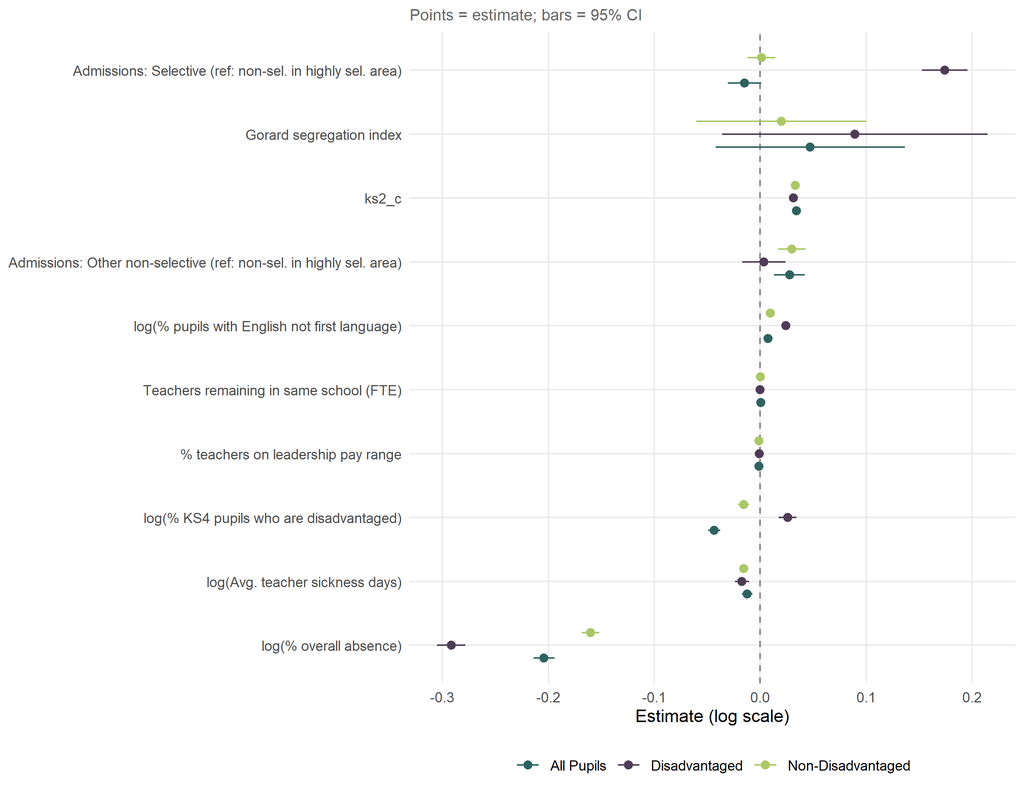

Figure 1: Fixed effect estimates with 95% confidence intervals (panel models)

```r
panel_coef_data <- map_dfr(names(panel_models), function(mn) {
  m <- panel_models[[mn]]
  fe <- as.data.frame(summary(m)$coefficients)
  fe$term <- rownames(fe)

  fe %>%
    filter(term != "(Intercept)") %>%
    transmute(
      model = outcome_labels[mn],
      term_raw = term,
      term_label = sapply(term, function(t) {
        raw <- gsub("^log\\((.+)\\)$", "\\1", t)
        lbl <- var_label(raw)
        if (grepl("^log\\(", t)) lbl <- paste0("log(", lbl, ")")
        lbl
      }),
      estimate = Estimate,
      se = `Std. Error`,
      ci_lo = Estimate - 1.96 * `Std. Error`,
      ci_hi = Estimate + 1.96 * `Std. Error`
    )
})

ggplot(panel_coef_data,
       aes(x = estimate, y = reorder(term_label, estimate),
           colour = model)) +
  geom_vline(xintercept = 0, linetype = "dashed", colour = "grey50") +
  geom_pointrange(aes(xmin = ci_lo, xmax = ci_hi),
                  position = position_dodge(width = 0.6), size = 0.4) +
  scale_colour_manual(values = c("All Pupils" = "#2e6260",
                                 "Disadvantaged" = "#4e3c56",
                                 "Non-Disadvantaged" = "#abc766"),
                      name = NULL) +
  labs(x = "Estimate (log scale)", y = NULL,
       subtitle = "Points = estimate; bars = 95% CI") +
  theme_pub
```

## 3.3 Random Effects & Model Fit

The multilevel model includes four levels of **random intercepts**, each allowing the baseline log(ATT8) to vary across groups:

1. **Academic year** (`year_label`) — captures system-wide year-on-year shifts in attainment (e.g. grade inflation, COVID recovery effects) that affect all schools equally within a given year.
2. **Ofsted rating** (`OFSTEDRATING_1`, harmonised to four levels) — allows schools with different inspection outcomes to have systematically different attainment baselines, beyond what the fixed-effect predictors explain.
3. **Government Office Region** (`gor_name`) — accounts for broad regional differences in attainment (e.g. London vs. the North East), which may reflect regional labour markets, funding patterns, or cultural factors.
4. **Local authority nested within region** (`LANAME:gor_name`) — the finest grouping level, capturing LA-specific effects such as local policy environments, demographic composition, or authority-level support services, over and above the regional baseline.

The table below reports the estimated variance for each random effect, along with the residual variance and overall model fit (marginal R², which reflects fixed effects only, and conditional R², which includes both fixed and random effects).

```r
panel_fit <- map_dfr(names(panel_models), function(mn) {
  m <- panel_models[[mn]]
  d <- panel_diag[[mn]]
  vc <- as.data.frame(VarCorr(m))

  # Extract variance for each grouping
  var_year   <- vc$vcov[vc$grp == "year_label"]
  var_ofsted <- vc$vcov[vc$grp == "OFSTEDRATING_1"]
  var_la     <- vc$vcov[vc$grp == "LANAME:gor_name"]
  var_region <- vc$vcov[vc$grp == "gor_name"]
  var_resid  <- d$sigma^2

  tibble(
    Model = outcome_labels[mn],
    var_year   = round(var_year, 6),
    var_ofsted = round(var_ofsted, 6),
    var_la     = round(var_la, 6),
    var_region = round(var_region, 6),
    var_resid  = round(var_resid, 6),
    r2m = round(d$r2_marginal, 4),
    r2c = round(d$r2_conditional, 4),
    N = d$n_obs
  )
})

names(panel_fit)[2:8] <- c(
  paste0("\u03c3\u00b2", "<sub>year</sub>"),
  paste0("\u03c3\u00b2", "<sub>Ofsted</sub>"),
  paste0("\u03c3\u00b2", "<sub>LA</sub>"),
  paste0("\u03c3\u00b2", "<sub>region</sub>"),
  paste0("\u03c3\u00b2", "<sub>resid</sub>"),
  "R\u00b2<sub>m</sub>",
  "R\u00b2<sub>c</sub>"
)

panel_fit %>%
  kable(format = "html", align = "lrrrrrrrrr", escape = FALSE) %>%
  kable_styling(bootstrap_options = c("striped", "hover", "condensed"),
                full_width = FALSE, font_size = 11)
```

Table 2: Random effect variance components and model fit statistics (panel models)

| Model | σ²<sub>year</sub> | σ²<sub>Ofsted</sub> | σ²<sub>LA</sub> | σ²<sub>region</sub> | σ²<sub>resid</sub> | R²<sub>m</sub> | R²<sub>c</sub> | N |
| --- | --- | --- | --- | --- | --- | --- | --- | --- |
| All Pupils | 0.002233 | 0.002167 | 0.000615 | 0.000172 | 0.007516 | 0.6635 | 0.8009 | 9047 |
| Disadvantaged | 0.003614 | 0.002778 | 0.001257 | 0.000588 | 0.013293 | 0.5591 | 0.7278 | 8936 |
| Non-Disadvantaged | 0.001917 | 0.001701 | 0.000592 | 0.000099 | 0.004922 | 0.6433 | 0.8098 | 8936 |

## 3.4 Random Intercepts

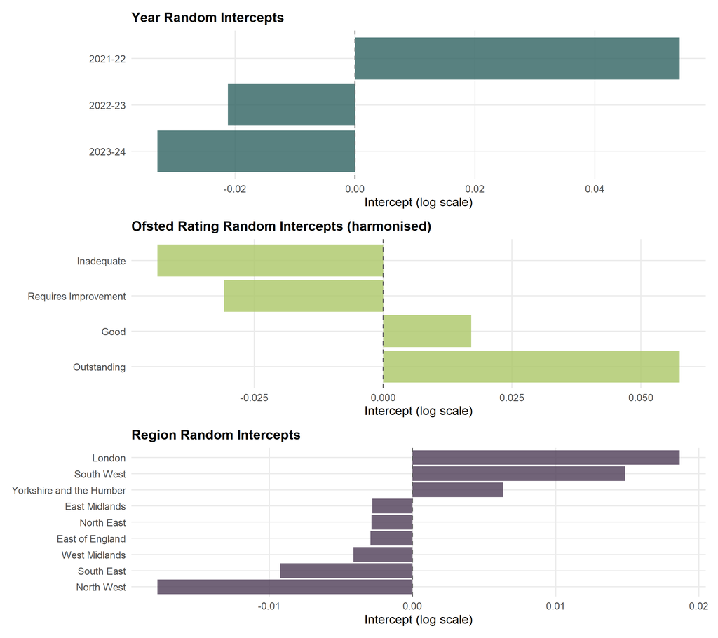

Figure 2: Random intercept estimates by grouping level (All Pupils panel model)

```r
m_all <- panel_models$all
re <- ranef(m_all)

# Year random effects
re_year <- tibble(
  year = rownames(re$year_label),
  intercept = re$year_label[, 1]
)

p_year <- ggplot(re_year, aes(x = reorder(year, intercept), y = intercept)) +
  geom_col(fill = "#2e6260", alpha = 0.8) +
  geom_hline(yintercept = 0, linetype = "dashed", colour = "grey40") +
  coord_flip() +
  labs(title = "Year Random Intercepts", x = NULL, y = "Intercept (log scale)") +
  theme_pub

# Ofsted random effects (harmonised)
re_ofsted <- tibble(
  rating = rownames(re$OFSTEDRATING_1),
  intercept = re$OFSTEDRATING_1[, 1]
)

p_ofsted <- ggplot(re_ofsted, aes(x = reorder(rating, -intercept), y = intercept)) +
  geom_col(fill = "#abc766", alpha = 0.8) +
  geom_hline(yintercept = 0, linetype = "dashed", colour = "grey40") +
  coord_flip() +
  labs(title = "Ofsted Rating Random Intercepts (harmonised)", x = NULL, y = "Intercept (log scale)") +
  theme_pub

# Region random effects
re_region <- tibble(
  region = rownames(re$gor_name),
  intercept = re$gor_name[, 1]
)

p_region <- ggplot(re_region, aes(x = reorder(region, intercept), y = intercept)) +
  geom_col(fill = "#4e3c56", alpha = 0.8) +
  geom_hline(yintercept = 0, linetype = "dashed", colour = "grey40") +
  coord_flip() +
  labs(title = "Region Random Intercepts", x = NULL, y = "Intercept (log scale)") +
  theme_pub

p_year / p_ofsted / p_region
```

## 3.5 Null Model: Variance Structure

The violin and box plots below show the distribution of Attainment 8 scores across the random-effect grouping variables. These visualise the between-group variance that the null (intercept-only) multilevel model captures — the same structure shown in more detail in the variance components table above.

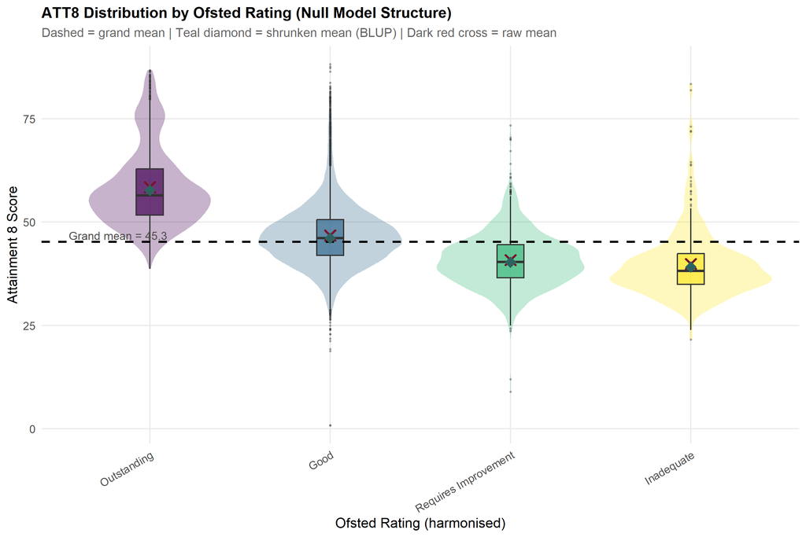

Figure 3: Distribution of Attainment 8 scores by Ofsted rating — visualising the null model variance structure

```r
# Fit null model: ATT8 with only Ofsted as random intercept
null_ofsted <- lmer(log(ATT8SCR) ~ 1 + (1 | OFSTEDRATING_1), data = model_data)
grand_mean_ofsted <- exp(fixef(null_ofsted)[1])

# Extract shrunken group means (BLUPs)
re_ofsted_null <- ranef(null_ofsted)$OFSTEDRATING_1 %>%
  as.data.frame() %>%
  rownames_to_column("OFSTEDRATING_1") %>%
  rename(blup = `(Intercept)`) %>%
  mutate(shrunken_mean = exp(fixef(null_ofsted)[1] + blup))

# Raw group means
raw_means_ofsted <- model_data %>%
  filter(!is.na(OFSTEDRATING_1), !is.na(ATT8SCR)) %>%
  group_by(OFSTEDRATING_1) %>%
  summarise(raw_mean = mean(ATT8SCR, na.rm = TRUE), n = n(), .groups = "drop") %>%
  left_join(re_ofsted_null, by = "OFSTEDRATING_1")

model_data %>%
  filter(!is.na(OFSTEDRATING_1), !is.na(ATT8SCR)) %>%
  ggplot(aes(x = OFSTEDRATING_1, y = ATT8SCR, fill = OFSTEDRATING_1)) +
  geom_violin(alpha = 0.3, colour = NA) +
  geom_boxplot(width = 0.15, alpha = 0.7, outlier.size = 0.5, outlier.alpha = 0.3) +
  geom_hline(yintercept = grand_mean_ofsted, linetype = "dashed",
             colour = "black", linewidth = 0.8) +
  geom_point(data = raw_means_ofsted, aes(y = raw_mean),
             shape = 4, size = 3, colour = "#7b132b", stroke = 1.2) +
  geom_point(data = raw_means_ofsted, aes(y = shrunken_mean),
             shape = 18, size = 4, colour = "#2e6260") +
  annotate("text", x = 0.55, y = grand_mean_ofsted + 1.5,
           label = paste0("Grand mean = ", round(grand_mean_ofsted, 1)),
           hjust = 0, size = 3.2, colour = "grey30") +
  labs(title = "ATT8 Distribution by Ofsted Rating (Null Model Structure)",
       subtitle = "Dashed = grand mean | Teal diamond = shrunken mean (BLUP) | Dark red cross = raw mean",
       x = "Ofsted Rating (harmonised)", y = "Attainment 8 Score") +
  theme_pub +
  theme(legend.position = "none",
        axis.text.x = element_text(angle = 30, hjust = 1))
```

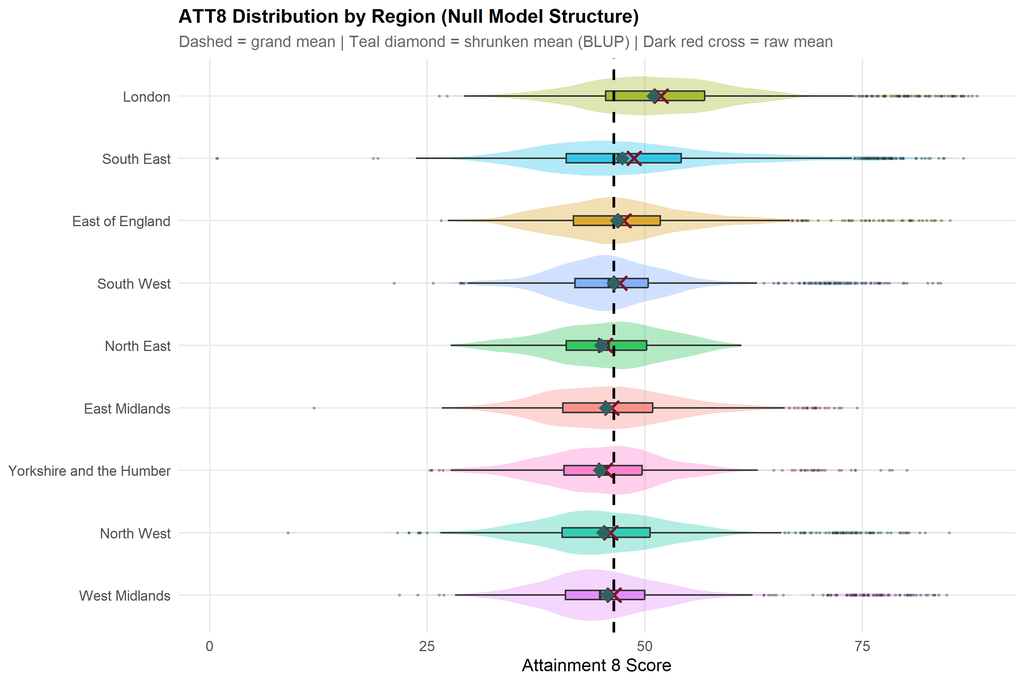

Figure 4: Distribution of Attainment 8 scores by Government Office Region — null model variance structure

```r
null_region <- lmer(log(ATT8SCR) ~ 1 + (1 | gor_name), data = model_data)
grand_mean_region <- exp(fixef(null_region)[1])

re_region_null <- ranef(null_region)$gor_name %>%
  as.data.frame() %>%
  rownames_to_column("gor_name") %>%
  rename(blup = `(Intercept)`) %>%
  mutate(shrunken_mean = exp(fixef(null_region)[1] + blup))

raw_means_region <- model_data %>%
  filter(!is.na(gor_name), !is.na(ATT8SCR)) %>%
  group_by(gor_name) %>%
  summarise(raw_mean = mean(ATT8SCR, na.rm = TRUE), n = n(), .groups = "drop") %>%
  left_join(re_region_null, by = "gor_name")

model_data %>%
  filter(!is.na(gor_name), !is.na(ATT8SCR)) %>%
  ggplot(aes(x = reorder(gor_name, ATT8SCR, FUN = median),
             y = ATT8SCR, fill = gor_name)) +
  geom_violin(alpha = 0.3, colour = NA) +
  geom_boxplot(width = 0.15, alpha = 0.7, outlier.size = 0.5, outlier.alpha = 0.3) +
  geom_hline(yintercept = grand_mean_region, linetype = "dashed",
             colour = "black", linewidth = 0.8) +
  geom_point(data = raw_means_region,
             aes(x = reorder(gor_name, raw_mean), y = raw_mean),
             shape = 4, size = 3, colour = "#7b132b", stroke = 1.2) +
  geom_point(data = raw_means_region,
             aes(x = reorder(gor_name, raw_mean), y = shrunken_mean),
             shape = 18, size = 4, colour = "#2e6260") +
  coord_flip() +
  labs(title = "ATT8 Distribution by Region (Null Model Structure)",
       subtitle = "Dashed = grand mean | Teal diamond = shrunken mean (BLUP) | Dark red cross = raw mean",
       x = NULL, y = "Attainment 8 Score") +
  theme_pub +
  theme(legend.position = "none")
```

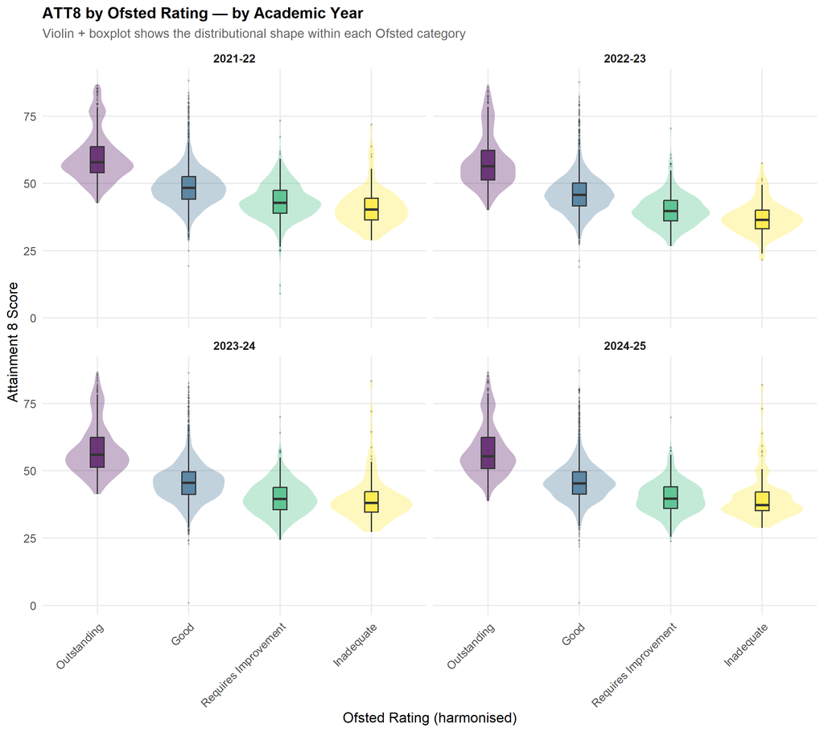

Figure 5: Distribution of Attainment 8 by Ofsted rating, faceted by academic year

```r
model_data %>%
  filter(!is.na(OFSTEDRATING_1), !is.na(ATT8SCR)) %>%
  ggplot(aes(x = OFSTEDRATING_1, y = ATT8SCR, fill = OFSTEDRATING_1)) +
  geom_violin(alpha = 0.3, colour = NA) +
  geom_boxplot(width = 0.15, alpha = 0.7, outlier.size = 0.3, outlier.alpha = 0.2) +
  facet_wrap(~ year_label, ncol = 2) +
  labs(title = "ATT8 by Ofsted Rating — by Academic Year",
       subtitle = "Violin + boxplot shows the distributional shape within each Ofsted category",
       x = "Ofsted Rating (harmonised)", y = "Attainment 8 Score") +
  theme_pub +
  theme(axis.text.x = element_text(angle = 45, hjust = 1),
        legend.position = "none")
```

## 3.6 Caterpillar Plot: LA Random Intercepts

The caterpillar plot below displays the estimated random intercepts for each local authority (nested within region), ordered by magnitude. Error bars show 95% confidence intervals (±1.96 posterior SE). Local authorities whose interval does not cross zero are meaningfully different from the overall mean, after accounting for fixed effects and other random effects. Brighton and Hove is highlighted in pink.

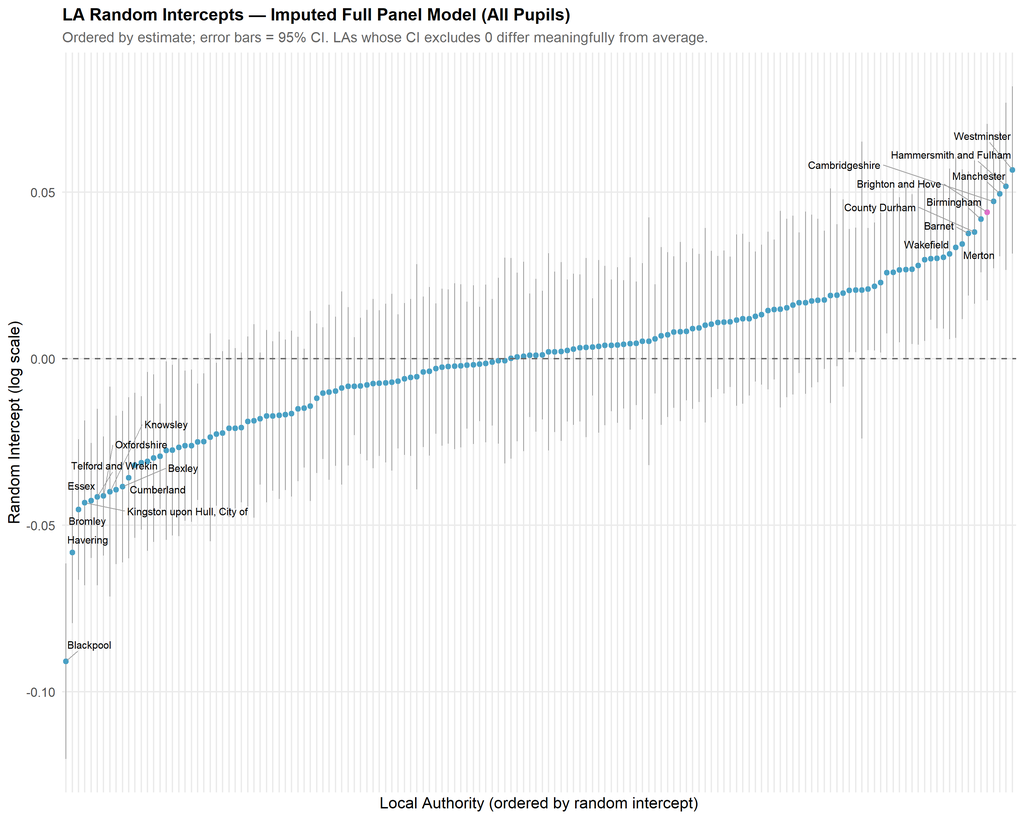

Figure 6: Caterpillar plot of LA random intercepts (imputed full panel model, All Pupils). Top and bottom 10 LAs labelled; Brighton and Hove in pink.

```r
library(ggrepel)

# Extract LA random effects with conditional variances
re_list_imp <- ranef(imputed_models$all, condVar = TRUE)
re_la <- as.data.frame(re_list_imp$`LANAME:gor_name`)
re_la$group <- rownames(re_list_imp$`LANAME:gor_name`)

# Posterior standard errors
se_la <- sqrt(attr(re_list_imp$`LANAME:gor_name`, "postVar")[1, 1, ])
re_la$se <- se_la

re_la <- re_la %>%
  mutate(
    la_name = sub(":.*$", "", group),
    ci_lo = `(Intercept)` - 1.96 * se,
    ci_hi = `(Intercept)` + 1.96 * se,
    sig = ci_lo > 0 | ci_hi < 0,
    highlight = ifelse(grepl("Brighton", la_name), "Brighton and Hove", "Other")
  )

# Top and bottom 10 for labelling (+ always include Brighton)
extreme_la <- c(
  head(re_la$la_name[order(re_la$`(Intercept)`)], 10),
  tail(re_la$la_name[order(re_la$`(Intercept)`)], 10)
)
if (any(grepl("Brighton", re_la$la_name))) {
  extreme_la <- unique(c(extreme_la,
                          re_la$la_name[grepl("Brighton", re_la$la_name)]))
}

ggplot(re_la, aes(x = reorder(group, `(Intercept)`), y = `(Intercept)`)) +
  geom_errorbar(aes(ymin = ci_lo, ymax = ci_hi),
                width = 0, colour = "grey60", linewidth = 0.3) +
  geom_point(aes(colour = highlight), size = 1.5) +
  geom_hline(yintercept = 0, linetype = "dashed", colour = "grey40") +
  geom_text_repel(
    data = re_la %>% filter(la_name %in% extreme_la),
    aes(label = la_name),
    size = 2.5, max.overlaps = 25, force = 4, nudge_y = 0.005,
    segment.colour = "grey60", segment.size = 0.3
  ) +
  scale_colour_manual(values = c("Other" = "#49a0c4",
                                  "Brighton and Hove" = "#e16fca"),
                      guide = "none") +
  labs(title = "LA Random Intercepts — Imputed Full Panel Model (All Pupils)",
       subtitle = "Ordered by estimate; error bars = 95% CI. LAs whose CI excludes 0 differ meaningfully from average.",
       x = "Local Authority (ordered by random intercept)",
       y = "Random Intercept (log scale)") +
  theme_pub +
  theme(axis.text.x = element_blank(), axis.ticks.x = element_blank())
```

The plots below show the same caterpillar format for **disadvantaged** and **non-disadvantaged** Attainment 8 models. The LA ordering will differ between the two — local authorities that perform well for disadvantaged pupils are not necessarily the same ones that perform well for non-disadvantaged pupils.

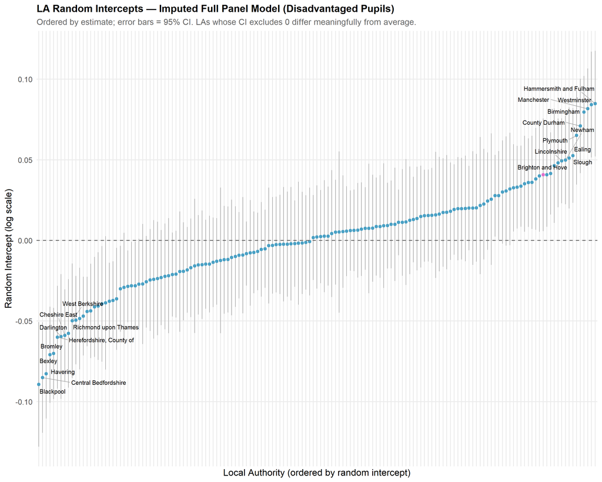

Figure 7: Caterpillar plot of LA random intercepts (imputed full panel model, Disadvantaged Pupils). Top and bottom 10 LAs labelled; Brighton and Hove in pink.

```r
plot_la_caterpillar(imputed_models$disadvantaged,
                    "LA Random Intercepts — Imputed Full Panel Model (Disadvantaged Pupils)")
```

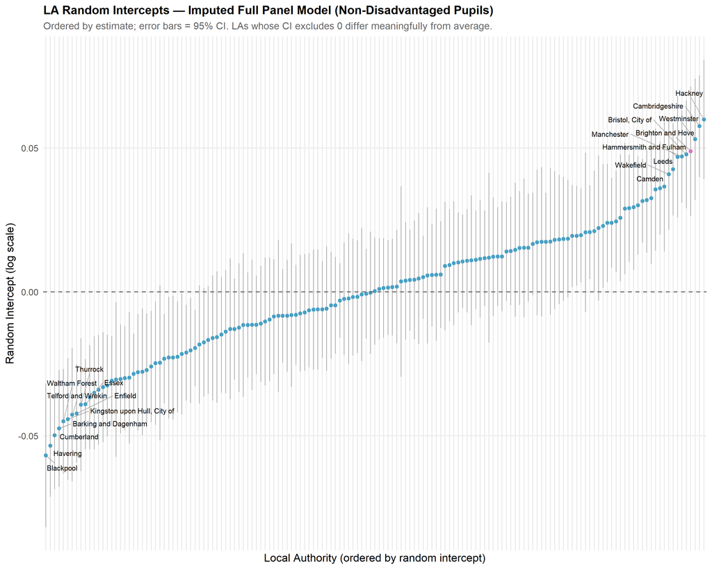

Figure 8: Caterpillar plot of LA random intercepts (imputed full panel model, Non-Disadvantaged Pupils). Top and bottom 10 LAs labelled; Brighton and Hove in pink.

```r
plot_la_caterpillar(imputed_models$non_disadvantaged,
                    "LA Random Intercepts — Imputed Full Panel Model (Non-Disadvantaged Pupils)")
```

## 3.7 Residual Diagnostics

Having examined the random effects structure, we now turn to the model’s residuals to check whether the key assumptions of the multilevel model are met: linearity, homoscedasticity (constant variance), and approximate normality of residuals.

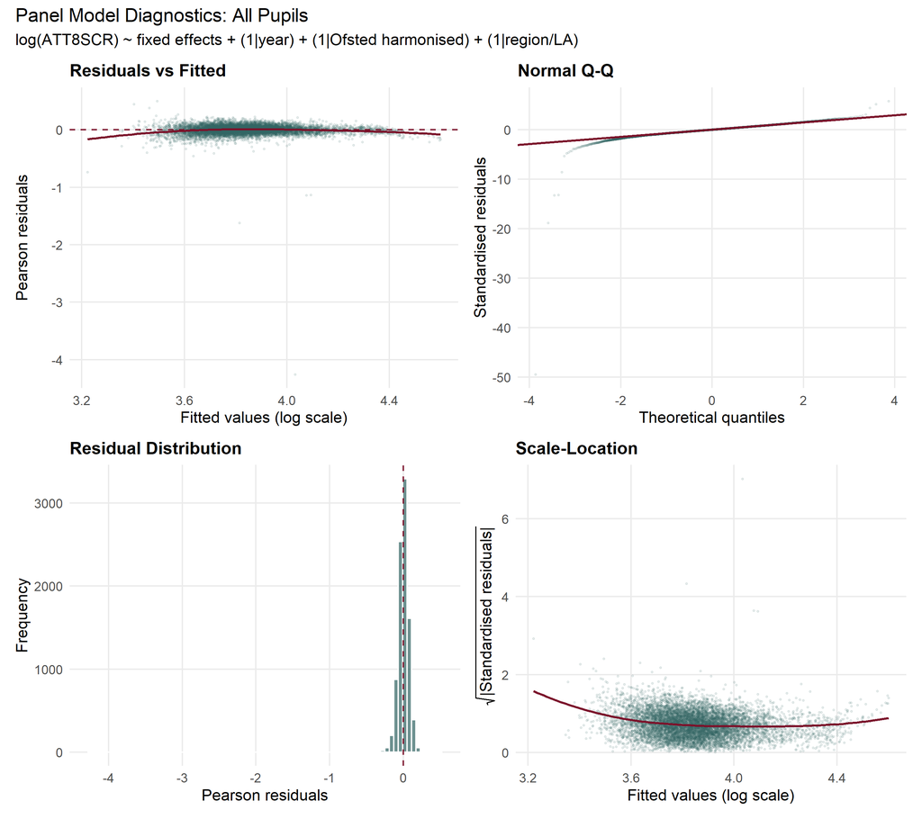

Figure 9: Residual diagnostics for the All Pupils panel model

```r
m_all <- panel_models$all

resid_data <- tibble(
  fitted = fitted(m_all),
  resid  = residuals(m_all, type = "pearson")
) %>%
  filter(!is.na(fitted), !is.na(resid)) %>%
  mutate(resid_std = resid / sd(resid))

p1 <- ggplot(resid_data, aes(x = fitted, y = resid)) +
  geom_point(alpha = 0.1, size = 0.5, colour = "#2e6260") +
  geom_hline(yintercept = 0, colour = "#7b132b", linetype = "dashed") +
  geom_smooth(method = "loess", se = FALSE, colour = "#7b132b", linewidth = 0.7) +
  labs(title = "Residuals vs Fitted", x = "Fitted values (log scale)", y = "Pearson residuals") +
  theme_pub

p2 <- ggplot(resid_data, aes(sample = resid_std)) +
  stat_qq(alpha = 0.1, size = 0.5, colour = "#2e6260") +
  stat_qq_line(colour = "#7b132b", linewidth = 0.7) +
  labs(title = "Normal Q-Q", x = "Theoretical quantiles", y = "Standardised residuals") +
  theme_pub

p3 <- ggplot(resid_data, aes(x = resid)) +
  geom_histogram(bins = 80, fill = "#2e6260", alpha = 0.7, colour = "white") +
  geom_vline(xintercept = 0, colour = "#7b132b", linetype = "dashed") +
  labs(title = "Residual Distribution", x = "Pearson residuals", y = "Frequency") +
  theme_pub

p4 <- ggplot(resid_data, aes(x = fitted, y = sqrt(abs(resid_std)))) +
  geom_point(alpha = 0.1, size = 0.5, colour = "#2e6260") +
  geom_smooth(method = "loess", se = FALSE, colour = "#7b132b", linewidth = 0.7) +
  labs(title = "Scale-Location", x = "Fitted values (log scale)",
       y = expression(sqrt("|Standardised residuals|"))) +
  theme_pub

(p1 + p2) / (p3 + p4) +
  plot_annotation(
    title = "Panel Model Diagnostics: All Pupils",
    subtitle = "log(ATT8SCR) ~ fixed effects + (1|year) + (1|Ofsted harmonised) + (1|region/LA)"
  )
```

# 4 Per-Year Models (Analysis B)

Separate models are fitted for each academic year with the same fixed-effect specification but without a year term. This allows all coefficients to vary freely across years, revealing whether relationships between predictors and attainment are stable or shifting over time.

## 4.1 Model Fit Comparison Across Years

```r
yearly_fit <- map_dfr(names(yearly_diag), function(yr) {
  map_dfr(names(yearly_diag[[yr]]), function(mn) {
    d <- yearly_diag[[yr]][[mn]]
    tibble(
      Year = yr,
      Outcome = outcome_labels[mn],
      N = ifelse(is.na(d$r2_marginal), NA_integer_, d$n_obs),
      r2m = round(d$r2_marginal, 4),
      r2c = round(d$r2_conditional, 4),
      sigma = round(d$sigma, 4)
    )
  })
})

names(yearly_fit)[4:6] <- c(
  "R\u00b2<sub>m</sub>",
  "R\u00b2<sub>c</sub>",
  "\u03c3"
)

yearly_fit %>%
  kable(format = "html", align = "llrrrr", escape = FALSE) %>%
  kable_styling(bootstrap_options = c("striped", "hover", "condensed"),
                full_width = FALSE, font_size = 11) %>%
  collapse_rows(columns = 1, valign = "top")
```

Table 3: Model fit statistics by year and outcome

| Year | Outcome | N | R²<sub>m</sub> | R²<sub>c</sub> | σ |
| --- | --- | --- | --- | --- | --- |
| 2021-22 | All Pupils | 2943 | 0.7053 | 0.7977 | 0.0810 |
|  | Disadvantaged | 2905 | 0.5857 | 0.6794 | 0.1152 |
|  | Non-Disadvantaged | 2905 | 0.6672 | 0.7679 | 0.0736 |
| 2022-23 | All Pupils | 2961 | 0.7534 | 0.8519 | 0.0710 |
|  | Disadvantaged | 2921 | 0.5987 | 0.7068 | 0.1151 |
|  | Non-Disadvantaged | 2921 | 0.6814 | 0.8033 | 0.0691 |
| 2023-24 | All Pupils | 3143 | 0.6649 | 0.7269 | 0.1041 |
|  | Disadvantaged | 3110 | 0.6408 | 0.7288 | 0.1163 |
|  | Non-Disadvantaged | 3110 | 0.7252 | 0.8086 | 0.0681 |

## 4.2 Coefficient Stability Across Years

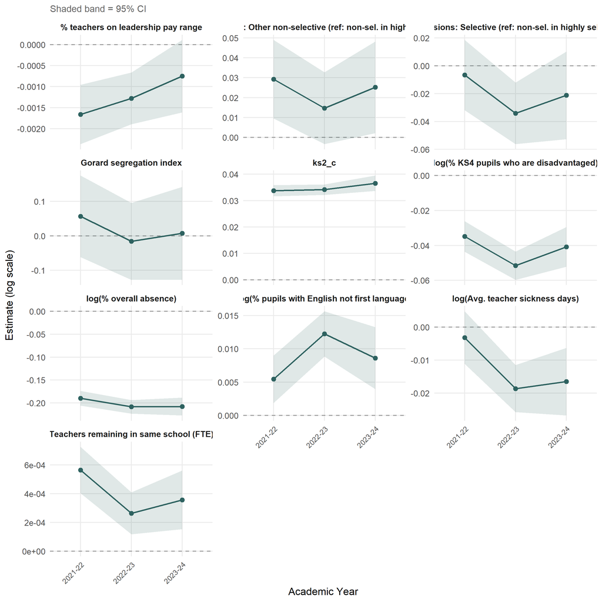

Figure 10: How fixed-effect estimates change across academic years (All Pupils models)

```r
yearly_coef_data <- map_dfr(names(yearly_models), function(yr) {
  m <- yearly_models[[yr]]$all
  if (is.null(m)) return(NULL)

  fe <- as.data.frame(summary(m)$coefficients)
  fe$term <- rownames(fe)

  fe %>%
    filter(term != "(Intercept)") %>%
    transmute(
      year = yr,
      term_raw = term,
      term_label = sapply(term, function(t) {
        raw <- gsub("^log\\((.+)\\)$", "\\1", t)
        lbl <- var_label(raw)
        if (grepl("^log\\(", t)) lbl <- paste0("log(", lbl, ")")
        lbl
      }),
      estimate = Estimate,
      se = `Std. Error`,
      ci_lo = Estimate - 1.96 * `Std. Error`,
      ci_hi = Estimate + 1.96 * `Std. Error`
    )
})

if (nrow(yearly_coef_data) > 0) {
  ggplot(yearly_coef_data,
         aes(x = year, y = estimate, group = 1)) +
    geom_hline(yintercept = 0, linetype = "dashed", colour = "grey60") +
    geom_ribbon(aes(ymin = ci_lo, ymax = ci_hi), alpha = 0.15, fill = "#2e6260") +
    geom_line(colour = "#2e6260", linewidth = 0.7) +
    geom_point(colour = "#2e6260", size = 2) +
    facet_wrap(~ term_label, scales = "free_y", ncol = 3) +
    labs(x = "Academic Year", y = "Estimate (log scale)",
         subtitle = "Shaded band = 95% CI") +
    theme_pub +
    theme(axis.text.x = element_text(angle = 45, hjust = 1, size = 8))
}
```

## 4.3 Side-by-Side Coefficient Table (Per-Year, All Pupils)

```r
yearly_coef_wide <- yearly_coef_data %>%
  mutate(
    # Look up p-values from the original models
    sig = map2_chr(year, term_raw, function(yr, term) {
      m <- yearly_models[[yr]]$all
      if (is.null(m)) return("")
      fe <- as.data.frame(summary(m)$coefficients)
      p <- fe[term, "Pr(>|t|)"]
      if (is.na(p)) "" else if (p < 0.001) "***" else if (p < 0.01) "**" else if (p < 0.05) "*" else ""
    }),
    cell = paste0(round(estimate, 4), sig)
  ) %>%
  select(term_label, year, cell) %>%
  pivot_wider(names_from = year, values_from = cell)

yearly_coef_wide %>%
  rename(Variable = term_label) %>%
  kable(align = c("l", rep("r", ncol(yearly_coef_wide) - 1))) %>%
  kable_styling(bootstrap_options = c("striped", "hover", "condensed"),
                full_width = FALSE, font_size = 11)
```

Table 4: Fixed effect estimates by year (All Pupils outcome). Significance: *** p<0.001, ** p<0.01, * p<0.05

| Variable | 2021-22 | 2022-23 | 2023-24 |
| --- | --- | --- | --- |
| log(% KS4 pupils who are disadvantaged) | -0.0349*** | -0.0516*** | -0.0408*** |
| log(% overall absence) | -0.1898*** | -0.2084*** | -0.2076*** |
| log(% pupils with English not first language) | 0.0054** | 0.0122*** | 0.0086*** |
| ks2_c | 0.0338*** | 0.0342*** | 0.0366*** |
| Admissions: Other non-selective (ref: non-sel. in highly sel. area) | 0.0293** | 0.0147 | 0.0252* |
| Admissions: Selective (ref: non-sel. in highly sel. area) | -0.0067 | -0.0342** | -0.0212 |
| Gorard segregation index | 0.0563 | -0.016 | 0.0077 |
| Teachers remaining in same school (FTE) | 6e-04*** | 3e-04*** | 4e-04*** |
| % teachers on leadership pay range | -0.0017*** | -0.0013*** | -8e-04 |
| log(Avg. teacher sickness days) | -0.0032 | -0.0186*** | -0.0165** |

# 5 Core Models (All 4 Years)

School Workforce Census variables (`remained_in_the_same_school`, `teachers_on_leadership_pay_range_percent`, `average_number_of_days_taken`) and KS2 prior attainment (`KS2ASS`, entered in the models as `ks2_c`) are not available for 2024-25; the relevant cohort’s primary assessments were cancelled during the pandemic. To enable cross-year comparison including the latest year, a **core specification** is fitted using only the 5 predictors available across all four years:

$$\log(y_{ij}) = \beta_0 + \beta_1\log(\text{FSM\%}) + \beta_2\log(\text{Absence\%}) + \beta_3\log(\text{EAL\%}) + \beta_4\text{Admissions} + \beta_5\text{Gorard} + u_{\text{year}} + u_{\text{Ofsted}} + u_{\text{region}} + u_{\text{LA}} + \varepsilon_{ij}$$

## 5.1 Core Panel: Fixed Effects

```r
core_panel_fe <- map_dfr(names(core_models), function(mn) {
  m <- core_models[[mn]]
  fe <- as.data.frame(summary(m)$coefficients)
  fe$term <- rownames(fe)

  fe %>%
    transmute(
      Model = outcome_labels[mn],
      Term = sapply(term, function(t) {
        raw <- gsub("^log\\((.+)\\)$", "\\1", t)
        lbl <- var_label(raw)
        if (grepl("^log\\(", t)) lbl <- paste0("log(", lbl, ")")
        lbl
      }),
      Estimate = round(Estimate, 4),
      `Std. Error` = round(`Std. Error`, 4),
      `t value` = round(`t value`, 2),
      `p value` = ifelse(`Pr(>|t|)` < 0.001, "< 0.001",
                         ifelse(`Pr(>|t|)` < 0.01, "< 0.01",
                                ifelse(`Pr(>|t|)` < 0.05, "< 0.05",
                                       round(`Pr(>|t|)`, 3))))
    )
})

core_panel_fe %>%
  kable(align = "llrrrr") %>%
  kable_styling(bootstrap_options = c("striped", "hover", "condensed"),
                full_width = FALSE, font_size = 11) %>%
  collapse_rows(columns = 1, valign = "top")
```

Table 5: Fixed effect estimates from core panel models (all 4 years, reduced specification)

|  | Model | Term | Estimate | Std. Error | t value | p value |
| --- | --- | --- | --- | --- | --- | --- |
| (Intercept)...1 | All Pupils | (Intercept) | 4.7841 | 0.0374 | 127.90 | < 0.001 |
|  | All Pupils | log(% KS4 pupils who are disadvantaged) | -0.1280 | 0.0026 | -50.05 | < 0.001 |
|  | All Pupils | log(% overall absence) | -0.2614 | 0.0047 | -55.26 | < 0.001 |
|  | All Pupils | log(% pupils with English not first language) | 0.0002 | 0.0013 | 0.16 | 0.873 |
|  | All Pupils | Admissions: Other non-selective (ref: non-sel. in highly sel. area) | 0.0123 | 0.0081 | 1.52 | 0.129 |
|  | All Pupils | Admissions: Selective (ref: non-sel. in highly sel. area) | 0.1614 | 0.0068 | 23.68 | < 0.001 |
|  | All Pupils | Gorard segregation index | -0.0673 | 0.0544 | -1.24 | 0.217 |
| (Intercept)...8 | Disadvantaged | (Intercept) | 4.4616 | 0.0458 | 97.49 | < 0.001 |
|  | Disadvantaged | log(% KS4 pupils who are disadvantaged) | -0.0482 | 0.0033 | -14.80 | < 0.001 |
|  | Disadvantaged | log(% overall absence) | -0.3418 | 0.0058 | -59.03 | < 0.001 |
|  | Disadvantaged | log(% pupils with English not first language) | 0.0178 | 0.0015 | 11.73 | < 0.001 |
|  | Disadvantaged | Admissions: Other non-selective (ref: non-sel. in highly sel. area) | -0.0120 | 0.0103 | -1.17 | 0.244 |
|  | Disadvantaged | Admissions: Selective (ref: non-sel. in highly sel. area) | 0.3402 | 0.0084 | 40.59 | < 0.001 |
|  | Disadvantaged | Gorard segregation index | -0.0592 | 0.0669 | -0.89 | 0.376 |
| (Intercept)...15 | Non-Disadvantaged | (Intercept) | 4.6883 | 0.0330 | 141.86 | < 0.001 |
|  | Non-Disadvantaged | log(% KS4 pupils who are disadvantaged) | -0.1054 | 0.0022 | -47.17 | < 0.001 |
|  | Non-Disadvantaged | log(% overall absence) | -0.2107 | 0.0040 | -53.28 | < 0.001 |
|  | Non-Disadvantaged | log(% pupils with English not first language) | 0.0033 | 0.0010 | 3.16 | < 0.01 |
|  | Non-Disadvantaged | Admissions: Other non-selective (ref: non-sel. in highly sel. area) | 0.0010 | 0.0074 | 0.13 | 0.894 |
|  | Non-Disadvantaged | Admissions: Selective (ref: non-sel. in highly sel. area) | 0.1683 | 0.0058 | 29.19 | < 0.001 |
|  | Non-Disadvantaged | Gorard segregation index | -0.1127 | 0.0503 | -2.24 | < 0.05 |

## 5.2 Core Panel: Random Effects & Model Fit

```r
core_panel_fit <- map_dfr(names(core_models), function(mn) {
  m <- core_models[[mn]]
  d <- core_diag[[mn]]
  vc <- as.data.frame(VarCorr(m))

  var_year   <- vc$vcov[vc$grp == "year_label"]
  var_ofsted <- vc$vcov[vc$grp == "OFSTEDRATING_1"]
  var_la     <- vc$vcov[vc$grp == "LANAME:gor_name"]
  var_region <- vc$vcov[vc$grp == "gor_name"]
  var_resid  <- d$sigma^2

  tibble(
    Model = outcome_labels[mn],
    var_year   = round(var_year, 6),
    var_ofsted = round(var_ofsted, 6),
    var_la     = round(var_la, 6),
    var_region = round(var_region, 6),
    var_resid  = round(var_resid, 6),
    r2m = round(d$r2_marginal, 4),
    r2c = round(d$r2_conditional, 4),
    N = d$n_obs
  )
})

names(core_panel_fit)[2:8] <- c(
  paste0("\u03c3\u00b2", "<sub>year</sub>"),
  paste0("\u03c3\u00b2", "<sub>Ofsted</sub>"),
  paste0("\u03c3\u00b2", "<sub>LA</sub>"),
  paste0("\u03c3\u00b2", "<sub>region</sub>"),
  paste0("\u03c3\u00b2", "<sub>resid</sub>"),
  "R\u00b2<sub>m</sub>",
  "R\u00b2<sub>c</sub>"
)

core_panel_fit %>%
  kable(format = "html", align = "lrrrrrrrrr", escape = FALSE) %>%
  kable_styling(bootstrap_options = c("striped", "hover", "condensed"),
                full_width = FALSE, font_size = 11)
```

Table 6: Random effect variance components and model fit statistics (core panel models)

| Model | σ²<sub>year</sub> | σ²<sub>Ofsted</sub> | σ²<sub>LA</sub> | σ²<sub>region</sub> | σ²<sub>resid</sub> | R²<sub>m</sub> | R²<sub>c</sub> | N |
| --- | --- | --- | --- | --- | --- | --- | --- | --- |
| All Pupils | 0.001121 | 0.002906 | 0.001468 | 0.001009 | 0.010372 | 0.5734 | 0.7378 | 12845 |
| Disadvantaged | 0.002415 | 0.003309 | 0.002183 | 0.002046 | 0.014964 | 0.5038 | 0.7020 | 12702 |
| Non-Disadvantaged | 0.000800 | 0.002192 | 0.001752 | 0.001117 | 0.006948 | 0.5326 | 0.7464 | 12702 |

## 5.3 Core Per-Year: Model Fit Comparison

```r
core_yearly_fit <- map_dfr(names(core_yearly_diag), function(yr) {
  map_dfr(names(core_yearly_diag[[yr]]), function(mn) {
    d <- core_yearly_diag[[yr]][[mn]]
    tibble(
      Year = yr,
      Outcome = outcome_labels[mn],
      N = ifelse(is.na(d$r2_marginal), NA_integer_, d$n_obs),
      r2m = round(d$r2_marginal, 4),
      r2c = round(d$r2_conditional, 4),
      sigma = round(d$sigma, 4)
    )
  })
})

names(core_yearly_fit)[4:6] <- c(
  "R\u00b2<sub>m</sub>",
  "R\u00b2<sub>c</sub>",
  "\u03c3"
)

core_yearly_fit %>%
  kable(format = "html", align = "llrrrr", escape = FALSE) %>%
  kable_styling(bootstrap_options = c("striped", "hover", "condensed"),
                full_width = FALSE, font_size = 11) %>%
  collapse_rows(columns = 1, valign = "top")
```

Table 7: Core model fit statistics by year and outcome (all 4 years)

| Year | Outcome | N | R²<sub>m</sub> | R²<sub>c</sub> | σ |
| --- | --- | --- | --- | --- | --- |
| 2021-22 | All Pupils | 3200 | 0.5821 | 0.7353 | 0.0954 |
|  | Disadvantaged | 3160 | 0.4940 | 0.6507 | 0.1222 |
|  | Non-Disadvantaged | 3160 | 0.5061 | 0.6980 | 0.0880 |
| 2022-23 | All Pupils | 3225 | 0.6401 | 0.7898 | 0.0871 |
|  | Disadvantaged | 3183 | 0.4990 | 0.6642 | 0.1254 |
|  | Non-Disadvantaged | 3183 | 0.5316 | 0.7276 | 0.0845 |
| 2023-24 | All Pupils | 3210 | 0.5646 | 0.6799 | 0.1147 |
|  | Disadvantaged | 3177 | 0.5574 | 0.7020 | 0.1235 |
|  | Non-Disadvantaged | 3177 | 0.5677 | 0.7388 | 0.0827 |
| 2024-25 | All Pupils | 3210 | 0.5725 | 0.6778 | 0.1114 |
|  | Disadvantaged | 3182 | 0.5804 | 0.7014 | 0.1194 |
|  | Non-Disadvantaged | 3182 | 0.5824 | 0.7447 | 0.0801 |

## 5.4 Core Per-Year: Coefficient Stability

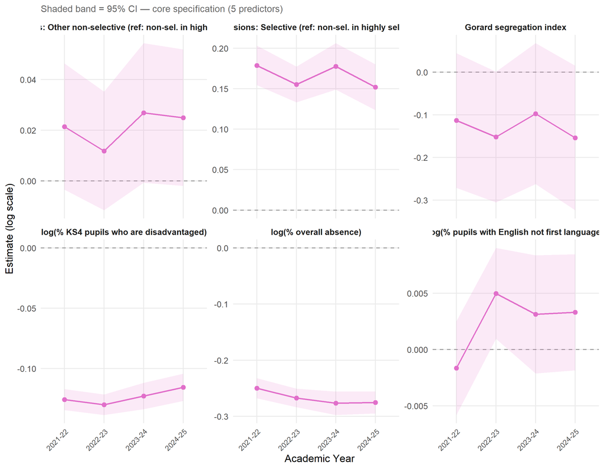

Figure 11: How core fixed-effect estimates change across all 4 academic years (All Pupils)

```r
core_yearly_coef_data <- map_dfr(names(core_yearly_models), function(yr) {
  m <- core_yearly_models[[yr]]$all
  if (is.null(m)) return(NULL)

  fe <- as.data.frame(summary(m)$coefficients)
  fe$term <- rownames(fe)

  fe %>%
    filter(term != "(Intercept)") %>%
    transmute(
      year = yr,
      term_raw = term,
      term_label = sapply(term, function(t) {
        raw <- gsub("^log\\((.+)\\)$", "\\1", t)
        lbl <- var_label(raw)
        if (grepl("^log\\(", t)) lbl <- paste0("log(", lbl, ")")
        lbl
      }),
      estimate = Estimate,
      se = `Std. Error`,
      ci_lo = Estimate - 1.96 * `Std. Error`,
      ci_hi = Estimate + 1.96 * `Std. Error`
    )
})

if (nrow(core_yearly_coef_data) > 0) {
  ggplot(core_yearly_coef_data,
         aes(x = year, y = estimate, group = 1)) +
    geom_hline(yintercept = 0, linetype = "dashed", colour = "grey60") +
    geom_ribbon(aes(ymin = ci_lo, ymax = ci_hi), alpha = 0.15, fill = "#e16fca") +
    geom_line(colour = "#e16fca", linewidth = 0.7) +
    geom_point(colour = "#e16fca", size = 2) +
    facet_wrap(~ term_label, scales = "free_y", ncol = 3) +
    labs(x = "Academic Year", y = "Estimate (log scale)",
         subtitle = "Shaded band = 95% CI — core specification (5 predictors)") +
    theme_pub +
    theme(axis.text.x = element_text(angle = 45, hjust = 1, size = 8))
}
```

## 5.5 Core Per-Year: Side-by-Side Coefficients

```r
core_yearly_coef_wide <- core_yearly_coef_data %>%
  mutate(
    sig = map2_chr(year, term_raw, function(yr, term) {
      m <- core_yearly_models[[yr]]$all
      if (is.null(m)) return("")
      fe <- as.data.frame(summary(m)$coefficients)
      p <- fe[term, "Pr(>|t|)"]
      if (is.na(p)) "" else if (p < 0.001) "***" else if (p < 0.01) "**" else if (p < 0.05) "*" else ""
    }),
    cell = paste0(round(estimate, 4), sig)
  ) %>%
  select(term_label, year, cell) %>%
  pivot_wider(names_from = year, values_from = cell)

core_yearly_coef_wide %>%
  rename(Variable = term_label) %>%
  kable(align = c("l", rep("r", ncol(core_yearly_coef_wide) - 1))) %>%
  kable_styling(bootstrap_options = c("striped", "hover", "condensed"),
                full_width = FALSE, font_size = 11)
```

Table 8: Core fixed effect estimates by year (All Pupils). Significance: *** p<0.001, ** p<0.01, * p<0.05

| Variable | 2021-22 | 2022-23 | 2023-24 | 2024-25 |
| --- | --- | --- | --- | --- |
| log(% KS4 pupils who are disadvantaged) | -0.1257*** | -0.1299*** | -0.1226*** | -0.1155*** |
| log(% overall absence) | -0.2497*** | -0.2671*** | -0.2765*** | -0.2751*** |
| log(% pupils with English not first language) | -0.0016 | 0.005* | 0.0031 | 0.0033 |
| Admissions: Other non-selective (ref: non-sel. in highly sel. area) | 0.0215 | 0.0119 | 0.0268 | 0.025 |
| Admissions: Selective (ref: non-sel. in highly sel. area) | 0.1787*** | 0.1552*** | 0.1775*** | 0.1519*** |
| Gorard segregation index | -0.1133 | -0.1521 | -0.0972 | -0.1542 |

# 6 Imputed Full Panel Models (Analysis E)

The imputed full model uses the same 9-predictor specification as Analysis A, but extends coverage to all four academic years by carry-forward imputing the four variables unavailable for 2024-25 (`KS2ASS`, from which `ks2_c` is derived, `remained_in_the_same_school`, `teachers_on_leadership_pay_range_percent`, `average_number_of_days_taken`). Each school’s 2023-24 value is used (or the 3-year mean as a fallback). This is the model used in the Shiny app.

$$\log(y_{ij}) = \mathbf{X}_{ij}\boldsymbol{\beta} + u_{\text{year}} + u_{\text{Ofsted}} + u_{\text{region}} + u_{\text{LA}} + \varepsilon_{ij}$$

## 6.1 Imputed Panel: Fixed Effects

```r
imputed_fe <- map_dfr(names(imputed_models), function(mn) {
  m <- imputed_models[[mn]]
  fe <- as.data.frame(summary(m)$coefficients)
  fe$term <- rownames(fe)

  fe %>%
    transmute(
      Model = outcome_labels[mn],
      Term = sapply(term, function(t) {
        raw <- gsub("^log\\((.+)\\)$", "\\1", t)
        lbl <- var_label(raw)
        if (grepl("^log\\(", t)) lbl <- paste0("log(", lbl, ")")
        lbl
      }),
      Estimate = round(Estimate, 4),
      `Std. Error` = round(`Std. Error`, 4),
      `t value` = round(`t value`, 2),
      `p value` = ifelse(`Pr(>|t|)` < 0.001, "< 0.001",
                         ifelse(`Pr(>|t|)` < 0.01, "< 0.01",
                                ifelse(`Pr(>|t|)` < 0.05, "< 0.05",
                                       round(`Pr(>|t|)`, 3))))
    )
})

imputed_fe %>%
  kable(align = "llrrrr") %>%
  kable_styling(bootstrap_options = c("striped", "hover", "condensed"),
                full_width = FALSE, font_size = 11) %>%
  collapse_rows(columns = 1, valign = "top")
```

Table 9: Fixed effect estimates from imputed full panel models (Analysis E: 9 predictors, all 4 years)

|  | Model | Term | Estimate | Std. Error | t value | p value |
| --- | --- | --- | --- | --- | --- | --- |
| (Intercept)...1 | All Pupils | (Intercept) | 4.2612 | 0.0371 | 114.98 | < 0.001 |
|  | All Pupils | log(% KS4 pupils who are disadvantaged) | -0.0498 | 0.0027 | -18.18 | < 0.001 |
|  | All Pupils | log(% overall absence) | -0.2073 | 0.0045 | -45.74 | < 0.001 |
|  | All Pupils | log(% pupils with English not first language) | 0.0070 | 0.0012 | 6.09 | < 0.001 |
|  | All Pupils | ks2_c | 0.0319 | 0.0007 | 48.46 | < 0.001 |
|  | All Pupils | Admissions: Other non-selective (ref: non-sel. in highly sel. area) | 0.0282 | 0.0070 | 4.06 | < 0.001 |
|  | All Pupils | Admissions: Selective (ref: non-sel. in highly sel. area) | -0.0040 | 0.0074 | -0.55 | 0.586 |
|  | All Pupils | Gorard segregation index | 0.0257 | 0.0442 | 0.58 | 0.561 |
|  | All Pupils | Teachers remaining in same school (FTE) | 0.0004 | 0.0000 | 8.99 | < 0.001 |
|  | All Pupils | % teachers on leadership pay range | -0.0009 | 0.0002 | -4.52 | < 0.001 |
|  | All Pupils | log(Avg. teacher sickness days) | -0.0132 | 0.0023 | -5.69 | < 0.001 |
| (Intercept)...12 | Disadvantaged | (Intercept) | 4.0345 | 0.0474 | 85.12 | < 0.001 |
|  | Disadvantaged | log(% KS4 pupils who are disadvantaged) | 0.0212 | 0.0038 | 5.61 | < 0.001 |
|  | Disadvantaged | log(% overall absence) | -0.3000 | 0.0058 | -51.63 | < 0.001 |
|  | Disadvantaged | log(% pupils with English not first language) | 0.0241 | 0.0015 | 16.25 | < 0.001 |
|  | Disadvantaged | ks2_c | 0.0283 | 0.0009 | 33.05 | < 0.001 |
|  | Disadvantaged | Admissions: Other non-selective (ref: non-sel. in highly sel. area) | 0.0049 | 0.0095 | 0.51 | 0.607 |
|  | Disadvantaged | Admissions: Selective (ref: non-sel. in highly sel. area) | 0.1831 | 0.0095 | 19.28 | < 0.001 |
|  | Disadvantaged | Gorard segregation index | 0.0524 | 0.0598 | 0.88 | 0.381 |
|  | Disadvantaged | Teachers remaining in same school (FTE) | 0.0000 | 0.0001 | -0.50 | 0.614 |
|  | Disadvantaged | % teachers on leadership pay range | -0.0006 | 0.0003 | -2.57 | < 0.05 |
|  | Disadvantaged | log(Avg. teacher sickness days) | -0.0175 | 0.0029 | -5.94 | < 0.001 |
| (Intercept)...23 | Non-Disadvantaged | (Intercept) | 4.1683 | 0.0321 | 129.78 | < 0.001 |
|  | Non-Disadvantaged | log(% KS4 pupils who are disadvantaged) | -0.0228 | 0.0023 | -9.75 | < 0.001 |
|  | Non-Disadvantaged | log(% overall absence) | -0.1640 | 0.0036 | -45.76 | < 0.001 |
|  | Non-Disadvantaged | log(% pupils with English not first language) | 0.0096 | 0.0009 | 10.44 | < 0.001 |
|  | Non-Disadvantaged | ks2_c | 0.0304 | 0.0005 | 57.48 | < 0.001 |
|  | Non-Disadvantaged | Admissions: Other non-selective (ref: non-sel. in highly sel. area) | 0.0286 | 0.0061 | 4.72 | < 0.001 |
|  | Non-Disadvantaged | Admissions: Selective (ref: non-sel. in highly sel. area) | 0.0128 | 0.0059 | 2.18 | < 0.05 |
|  | Non-Disadvantaged | Gorard segregation index | 0.0030 | 0.0392 | 0.08 | 0.938 |
|  | Non-Disadvantaged | Teachers remaining in same school (FTE) | 0.0004 | 0.0000 | 10.16 | < 0.001 |
|  | Non-Disadvantaged | % teachers on leadership pay range | -0.0010 | 0.0002 | -6.21 | < 0.001 |
|  | Non-Disadvantaged | log(Avg. teacher sickness days) | -0.0164 | 0.0018 | -9.06 | < 0.001 |

## 6.2 Imputed Panel: Coefficient Comparison Plot

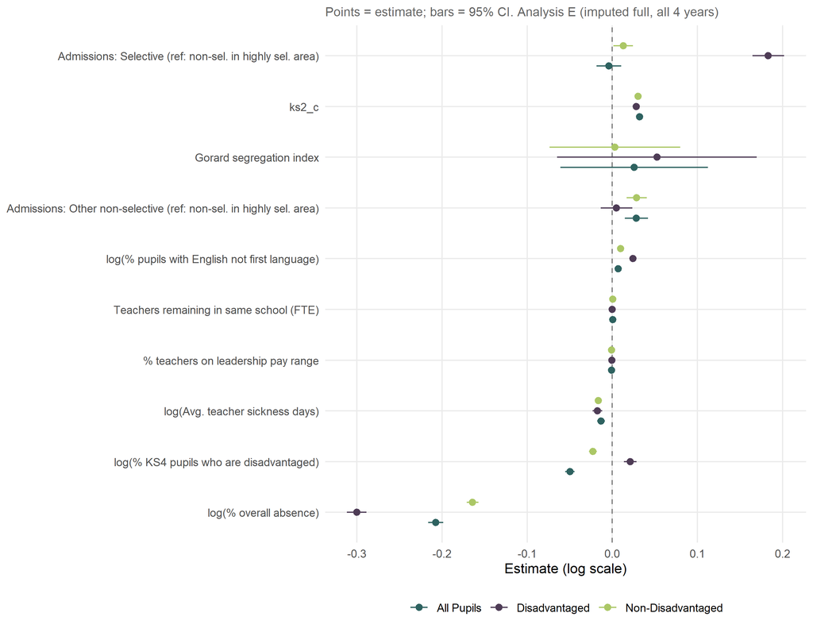

Figure 12: Fixed effect estimates with 95% confidence intervals (imputed full panel models, Analysis E)

```r
imputed_coef_data <- map_dfr(names(imputed_models), function(mn) {
  m <- imputed_models[[mn]]
  fe <- as.data.frame(summary(m)$coefficients)
  fe$term <- rownames(fe)

  fe %>%
    filter(term != "(Intercept)") %>%
    transmute(
      model = outcome_labels[mn],
      term_raw = term,
      term_label = sapply(term, function(t) {
        raw <- gsub("^log\\((.+)\\)$", "\\1", t)
        lbl <- var_label(raw)
        if (grepl("^log\\(", t)) lbl <- paste0("log(", lbl, ")")
        lbl
      }),
      estimate = Estimate,
      se = `Std. Error`,
      ci_lo = Estimate - 1.96 * `Std. Error`,
      ci_hi = Estimate + 1.96 * `Std. Error`
    )
})

ggplot(imputed_coef_data,
       aes(x = estimate, y = reorder(term_label, estimate),
           colour = model)) +
  geom_vline(xintercept = 0, linetype = "dashed", colour = "grey50") +
  geom_pointrange(aes(xmin = ci_lo, xmax = ci_hi),
                  position = position_dodge(width = 0.6), size = 0.4) +
  scale_colour_manual(values = c("All Pupils" = "#2e6260",
                                 "Disadvantaged" = "#4e3c56",
                                 "Non-Disadvantaged" = "#abc766"),
                      name = NULL) +
  labs(x = "Estimate (log scale)", y = NULL,
       subtitle = "Points = estimate; bars = 95% CI. Analysis E (imputed full, all 4 years)") +
  theme_pub
```

## 6.3 Imputed Panel: Random Effects & Model Fit

```r
imputed_fit <- map_dfr(names(imputed_models), function(mn) {
  m <- imputed_models[[mn]]
  d <- imputed_diag[[mn]]
  vc <- as.data.frame(VarCorr(m))

  var_year   <- vc$vcov[vc$grp == "year_label"]
  var_ofsted <- vc$vcov[vc$grp == "OFSTEDRATING_1"]
  var_la     <- vc$vcov[vc$grp == "LANAME:gor_name"]
  var_region <- vc$vcov[vc$grp == "gor_name"]
  var_resid  <- d$sigma^2

  tibble(
    Model = outcome_labels[mn],
    var_year   = round(var_year, 6),
    var_ofsted = round(var_ofsted, 6),
    var_la     = round(var_la, 6),
    var_region = round(var_region, 6),
    var_resid  = round(var_resid, 6),
    r2m = round(d$r2_marginal, 4),
    r2c = round(d$r2_conditional, 4),
    N = d$n_obs
  )
})

names(imputed_fit)[2:8] <- c(
  paste0("\u03c3\u00b2", "<sub>year</sub>"),
  paste0("\u03c3\u00b2", "<sub>Ofsted</sub>"),
  paste0("\u03c3\u00b2", "<sub>LA</sub>"),
  paste0("\u03c3\u00b2", "<sub>region</sub>"),
  paste0("\u03c3\u00b2", "<sub>resid</sub>"),
  "R\u00b2<sub>m</sub>",
  "R\u00b2<sub>c</sub>"
)

imputed_fit %>%
  kable(format = "html", align = "lrrrrrrrrr", escape = FALSE) %>%
  kable_styling(bootstrap_options = c("striped", "hover", "condensed"),
                full_width = FALSE, font_size = 11)
```

Table 10: Random effect variance components and model fit statistics (imputed full panel models, Analysis E)

| Model | σ²<sub>year</sub> | σ²<sub>Ofsted</sub> | σ²<sub>LA</sub> | σ²<sub>region</sub> | σ²<sub>resid</sub> | R²<sub>m</sub> | R²<sub>c</sub> | N |
| --- | --- | --- | --- | --- | --- | --- | --- | --- |
| All Pupils | 0.002008 | 0.002031 | 0.000680 | 0.000189 | 0.008455 | 0.6512 | 0.7793 | 12199 |
| Disadvantaged | 0.003565 | 0.002652 | 0.001357 | 0.000660 | 0.013407 | 0.5642 | 0.7300 | 12060 |
| Non-Disadvantaged | 0.001576 | 0.001517 | 0.000703 | 0.000138 | 0.005084 | 0.6483 | 0.8017 | 12060 |

## 6.4 Analysis A vs Analysis E: Coefficient Comparison

Adding one year of carry-forward imputed data (Analysis E) produces coefficients that are very close to the original 3-year full model (Analysis A). This is reassuring: three-quarters of the data is identical, and the imputed fourth year uses conservative carry-forward values.

```r
# Helper: relabel raw lmer coefficient names to human-readable form
relabel_terms <- function(term) {
  case_when(
    term == "(Intercept)" ~ "(Intercept)",
    term == "log(PTFSM6CLA1A)" ~ "log(% FSM)",
    term == "log(PERCTOT)" ~ "log(% Absence)",
    term == "log(PNUMEAL)" ~ "log(% EAL)",
    term == "ks2_c" ~ "Mean KS2 Prior Attainment",
    term == "gorard_segregation" ~ "Gorard Segregation",
    term == "ADMPOL_PTOTHER NON SEL" ~ "Admissions: Other non-selective (ref: non-sel. in highly sel. area)",
    term == "ADMPOL_PTSEL" ~ "Admissions: Selective (ref: non-sel. in highly sel. area)",
    term == "remained_in_the_same_school" ~ "Teacher Retention",
    term == "teachers_on_leadership_pay_range_percent" ~ "Leadership Pay %",
    term == "log(average_number_of_days_taken)" ~ "log(Teacher Sickness)",
    TRUE ~ term
  )
}

a_vs_e <- bind_rows(
  tibble(Analysis = "A (Full, 3 yrs)",
         Term = names(fixef(panel_models$all)),
         `All Pupils` = fixef(panel_models$all),
         Disadvantaged = fixef(panel_models$disadvantaged),
         `Non-Disadvantaged` = fixef(panel_models$non_disadvantaged)),
  tibble(Analysis = "E (Imputed, 4 yrs)",
         Term = names(fixef(imputed_models$all)),
         `All Pupils` = fixef(imputed_models$all),
         Disadvantaged = fixef(imputed_models$disadvantaged),
         `Non-Disadvantaged` = fixef(imputed_models$non_disadvantaged))
) %>%
  mutate(Term = relabel_terms(Term),
         across(where(is.numeric), \(x) round(x, 5)))

a_vs_e %>%
  kable(align = "llrrr") %>%
  kable_styling(bootstrap_options = c("striped", "hover", "condensed"),
                full_width = FALSE, font_size = 11) %>%
  collapse_rows(columns = 1, valign = "top")
```

Table 11: Coefficient comparison: Analysis A (3-year full) vs Analysis E (4-year imputed full)

| Analysis | Term | All Pupils | Disadvantaged | Non-Disadvantaged |
| --- | --- | --- | --- | --- |
| A (Full, 3 yrs) | (Intercept) | 4.23416 | 4.00585 | 4.13233 |
|  | log(% FSM) | -0.04344 | 0.02594 | -0.01568 |
|  | log(% Absence) | -0.20412 | -0.29165 | -0.16021 |
|  | log(% EAL) | 0.00729 | 0.02405 | 0.00943 |
|  | Mean KS2 Prior Attainment | 0.03429 | 0.03119 | 0.03307 |
|  | Admissions: Other non-selective (ref: non-sel. in highly sel. area) | 0.02767 | 0.00339 | 0.03008 |
|  | Admissions: Selective (ref: non-sel. in highly sel. area) | -0.01477 | 0.17419 | 0.00121 |
|  | Gorard Segregation | 0.04726 | 0.08945 | 0.01989 |
|  | Teacher Retention | 0.00042 | -0.00007 | 0.00037 |
|  | Leadership Pay % | -0.00117 | -0.00085 | -0.00122 |
|  | log(Teacher Sickness) | -0.01238 | -0.01716 | -0.01540 |
| E (Imputed, 4 yrs) | (Intercept) | 4.26118 | 4.03448 | 4.16831 |
|  | log(% FSM) | -0.04981 | 0.02116 | -0.02276 |
|  | log(% Absence) | -0.20732 | -0.30003 | -0.16403 |
|  | log(% EAL) | 0.00704 | 0.02413 | 0.00960 |
|  | Mean KS2 Prior Attainment | 0.03187 | 0.02827 | 0.03037 |
|  | Admissions: Other non-selective (ref: non-sel. in highly sel. area) | 0.02824 | 0.00487 | 0.02857 |
|  | Admissions: Selective (ref: non-sel. in highly sel. area) | -0.00401 | 0.18308 | 0.01276 |
|  | Gorard Segregation | 0.02571 | 0.05241 | 0.00303 |
|  | Teacher Retention | 0.00043 | -0.00003 | 0.00038 |
|  | Leadership Pay % | -0.00090 | -0.00065 | -0.00096 |
|  | log(Teacher Sickness) | -0.01316 | -0.01746 | -0.01641 |

# 7 Stepwise Model Building

The table below shows how the model develops as predictors are added, using the All Pupils outcome. This stepwise approach reveals **confounding** and **mediating** relationships between variables — when a coefficient changes substantially as new predictors enter, it indicates that the earlier estimate was partly capturing the effect of the omitted variable.

Five nested models are fitted to the same data (Analysis E, all 4 years):

```r
# ---- Prepare data ----
step_data <- imputed_model_data %>%
  filter(!is.na(ATT8SCR), ATT8SCR > 0)

# ---- Fit 5 nested models ----
m1 <- lm(log(ATT8SCR) ~ log(PTFSM6CLA1A),
         data = step_data)

m2 <- lm(log(ATT8SCR) ~ log(PTFSM6CLA1A) + log(PERCTOT),
         data = step_data)

m3 <- lm(log(ATT8SCR) ~ log(PTFSM6CLA1A) + log(PERCTOT) + ks2_c,
         data = step_data)

m4 <- lm(log(ATT8SCR) ~ log(PTFSM6CLA1A) + log(PERCTOT) + log(PNUMEAL) +
           ks2_c + ADMPOL_PT + gorard_segregation +
           remained_in_the_same_school +
           teachers_on_leadership_pay_range_percent +
           log(average_number_of_days_taken),
         data = step_data)

m5 <- lmer(log(ATT8SCR) ~ log(PTFSM6CLA1A) + log(PERCTOT) + log(PNUMEAL) +
             ks2_c + ADMPOL_PT + gorard_segregation +
             remained_in_the_same_school +
             teachers_on_leadership_pay_range_percent +
             log(average_number_of_days_taken) +
             (1 | year_label) + (1 | OFSTEDRATING_1) + (1 | gor_name/LANAME),
           data = step_data, REML = TRUE, na.action = na.exclude,
           control = lmerControl(optimizer = "bobyqa",
                                 optCtrl = list(maxfun = 20000)))

# ---- Helper: extract coefficients with stars ----
extract_coefs <- function(model, is_lmer = FALSE) {
  s <- summary(model)$coefficients
  df <- as.data.frame(s)
  df$term <- rownames(df)

  p_col <- if ("Pr(>|t|)" %in% names(df)) "Pr(>|t|)" else "Pr(>|z|)"
  t_col <- if ("t value" %in% names(df)) "t value" else "z value"

  df %>%
    transmute(
      term = term,
      estimate = Estimate,
      t_value = .data[[t_col]],
      p_value = .data[[p_col]],
      stars = case_when(
        p_value < 0.001 ~ "***",
        p_value < 0.01  ~ "**",
        p_value < 0.05  ~ "*",
        TRUE ~ ""
      ),
      est_display = paste0(format(round(estimate, 3), nsmall = 3), stars),
      t_display = format(round(t_value, 2), nsmall = 2)
    )
}

c1 <- extract_coefs(m1)
c2 <- extract_coefs(m2)
c3 <- extract_coefs(m3)
c4 <- extract_coefs(m4)
c5 <- extract_coefs(m5, is_lmer = TRUE)

# ---- Build unified term list (in model order) ----
# Use Model 5 (full) order, then add any terms not in it
term_order <- c5$term
all_terms <- c(term_order, setdiff(unique(c(c1$term, c2$term, c3$term, c4$term)), term_order))

# ---- Assemble fixed effects table ----
step_tbl <- tibble(term = all_terms) %>%
  left_join(c1 %>% select(term, est1 = est_display, t1 = t_display), by = "term") %>%
  left_join(c2 %>% select(term, est2 = est_display, t2 = t_display), by = "term") %>%
  left_join(c3 %>% select(term, est3 = est_display, t3 = t_display), by = "term") %>%
  left_join(c4 %>% select(term, est4 = est_display, t4 = t_display), by = "term") %>%
  left_join(c5 %>% select(term, est5 = est_display, t5 = t_display), by = "term") %>%
  mutate(across(everything(), \(x) replace_na(x, ""))) %>%
  mutate(term = relabel_terms(term))

n_fixed <- nrow(step_tbl)

# ---- Random effects (Model 5 only) ----
vc <- as.data.frame(VarCorr(m5))
# vc has columns: grp, var1, var2, vcov, sdcor

re_rows <- tibble(
  term = c("", paste0("  ", vc$grp)),
  est1 = "", t1 = "",
  est2 = "", t2 = "",
  est3 = "", t3 = "",
  est4 = "", t4 = "",
  est5 = c("", format(round(vc$sdcor, 3), nsmall = 3)),
  t5   = c("", rep("(SD)", nrow(vc)))
)
# Label the header row
re_rows$term[1] <- "Random effects"
re_rows$est5[1] <- ""
re_rows$t5[1] <- ""

# Clean up group names for display
re_rows <- re_rows %>%
  mutate(term = case_when(
    term == "Random effects" ~ "Random effects",
    grepl("LANAME:gor_name", term) ~ "  LA (nested in region)",
    grepl("gor_name", term) & !grepl("LANAME", term) ~ "  Region",
    grepl("OFSTEDRATING_1", term) ~ "  Ofsted rating",
    grepl("year_label", term) ~ "  Year",
    grepl("Residual", term) ~ "  Residual",
    TRUE ~ term
  ))

# ---- R² and N rows ----
r2_m1 <- round(summary(m1)$r.squared, 4)
r2_m2 <- round(summary(m2)$r.squared, 4)
r2_m3 <- round(summary(m3)$r.squared, 4)
r2_m4 <- round(summary(m4)$r.squared, 4)
r2_m5 <- performance::r2(m5)
r2m_m5 <- round(r2_m5$R2_marginal, 4)
r2c_m5 <- round(r2_m5$R2_conditional, 4)

n_obs <- nrow(step_data)

footer_rows <- tibble(
  term = c("", "R²", "R² (conditional)", "N"),
  est1 = c("", as.character(r2_m1), "", format(n_obs, big.mark = ",")),
  t1   = c("", "", "", ""),
  est2 = c("", as.character(r2_m2), "", format(n_obs, big.mark = ",")),
  t2   = c("", "", "", ""),
  est3 = c("", as.character(r2_m3), "", format(n_obs, big.mark = ",")),
  t3   = c("", "", "", ""),
  est4 = c("", as.character(r2_m4), "", format(n_obs, big.mark = ",")),
  t4   = c("", "", "", ""),
  est5 = c("", as.character(r2m_m5), as.character(r2c_m5), format(n_obs, big.mark = ",")),
  t5   = c("", "(marginal)", "(fixed + random)", "")
)

full_tbl <- bind_rows(step_tbl, re_rows, footer_rows)

# ---- Render with kableExtra ----
names(full_tbl) <- c("Variable",
                      "Est.", "t",
                      "Est. ", "t ",
                      "Est.  ", "t  ",
                      "Est.   ", "t   ",
                      "Est.    ", "t    ")

kbl(full_tbl, format = "html", align = "lrlrlrlrlrl", escape = FALSE) %>%
  kable_styling(bootstrap_options = c("striped", "hover", "condensed"),
                full_width = FALSE, font_size = 10) %>%
  add_header_above(c(" " = 1,
                      "Model 1:\nFSM only" = 2,
                      "Model 2:\n+ Absence" = 2,
                      "Model 3:\n+ Prior att." = 2,
                      "Model 4:\nAll fixed" = 2,
                      "Model 5:\nFull multilevel" = 2)) %>%
  row_spec(n_fixed + 1, bold = TRUE, extra_css = "border-top: 2px solid #666;") %>%
  row_spec(n_fixed + nrow(re_rows) + 1, extra_css = "border-top: 2px solid #666;") %>%
  row_spec(n_fixed + nrow(re_rows) + 2, bold = TRUE) %>%
  row_spec(n_fixed + nrow(re_rows) + 3, bold = TRUE) %>%
  row_spec(n_fixed + nrow(re_rows) + 4, bold = TRUE) %>%
  footnote(general = "Significance: *** p < 0.001, ** p < 0.01, * p < 0.05. Models 1–4 are OLS; Model 5 is a multilevel model (lmer) with random intercepts. Random effects shown as standard deviations.",
           general_title = "")
```

Table 12: Stepwise model building: All Pupils (Analysis E data)

| Variable | Model 1: FSM only Est. | Model 1: FSM only t | Model 2: + Absence Est. | Model 2: + Absence t | Model 3: + Prior att. Est. | Model 3: + Prior att. t | Model 4: All fixed Est. | Model 4: All fixed t | Model 5: Full multilevel Est. | Model 5: Full multilevel t |
| --- | --- | --- | --- | --- | --- | --- | --- | --- | --- | --- |
| (Intercept) | 4.473*** | 621.25 | 5.006*** | 579.97 | 4.412*** | 345.92 | 4.304*** | 263.27 | 4.261*** | 114.98 |
| log(% FSM) | -0.201*** | -88.94 | -0.122*** | -59.66 | -0.047*** | -21.04 | -0.054*** | -21.47 | -0.050*** | -18.18 |
| log(% Absence) |  |  | -0.364*** | -82.87 | -0.259*** | -60.47 | -0.229*** | -49.98 | -0.207*** | -45.74 |
| log(% EAL) |  |  |  |  |  |  | 0.013*** | 12.83 | 0.007*** | 6.09 |
| Mean KS2 Prior Attainment |  |  |  |  | 0.031*** | 58.18 | 0.030*** | 46.70 | 0.032*** | 48.46 |
| Admissions: Other non-selective (ref: non-sel. in highly sel. area) |  |  |  |  |  |  | 0.039*** | 8.73 | 0.028*** | 4.06 |
| Admissions: Selective (ref: non-sel. in highly sel. area) |  |  |  |  |  |  | 0.019* | 2.44 | -0.004 | -0.55 |
| Gorard Segregation |  |  |  |  |  |  | 0.075** | 2.84 | 0.026 | 0.58 |
| Teacher Retention |  |  |  |  |  |  | 0.001*** | 11.66 | 0.000*** | 8.99 |
| Leadership Pay % |  |  |  |  |  |  | -0.001*** | -5.45 | -0.001*** | -4.52 |
| log(Teacher Sickness) |  |  |  |  |  |  | -0.013*** | -5.20 | -0.013*** | -5.69 |
| Random effects |  |  |  |  |  |  |  |  |  |  |
| LA (nested in region) |  |  |  |  |  |  |  |  | 0.026 | (SD) |
| Region |  |  |  |  |  |  |  |  | 0.014 | (SD) |
| Ofsted rating |  |  |  |  |  |  |  |  | 0.045 | (SD) |
| Year |  |  |  |  |  |  |  |  | 0.045 | (SD) |
| Residual |  |  |  |  |  |  |  |  | 0.092 | (SD) |
| R² | 0.3932 |  | 0.6117 |  | 0.6961 |  | 0.7093 |  | 0.6512 | (marginal) |
| R² (conditional) |  |  |  |  |  |  |  |  | 0.7793 | (fixed + random) |
| N | 12,210 |  | 12,210 |  | 12,210 |  | 12,210 |  | 12,210 |  |

Significance: *** p < 0.001, ** p < 0.01, * p < 0.05. Models 1–4 are OLS; Model 5 is a multilevel model (lmer) with random intercepts. Random effects shown as standard deviations.

### 7.0.1 What the stepwise results reveal

**Model 1 → Model 2 (adding absence):** When FSM is the sole predictor, its coefficient is -0.201 — but when absence is added in Model 2, the FSM coefficient shifts to -0.122. This change reveals **confounding**: schools with higher FSM rates also tend to have higher absence rates, so Model 1’s FSM coefficient was partly capturing the absence–attainment relationship. The absence coefficient itself (-0.364) is strongly negative, confirming that higher absence is associated with lower attainment. R² increases from 0.3932 to 0.6117.

**Model 3 → Model 4 (adding remaining fixed effects):** The FSM coefficient shifts further to -0.054 as EAL, admissions policy, segregation, and workforce variables enter. The absence coefficient moves from -0.259 to -0.229. R² rises to 0.7093, showing that the full set of school-level characteristics explains more variation, though the incremental gain from these six variables is more modest than the jump from adding prior attainment alone.

**Model 4 → Model 5 (adding random effects):** The fixed-effect coefficients are broadly similar (R²<sub>m</sub> = 0.6512), but the conditional R² (R²<sub>c</sub> = 0.7793) shows a substantial jump. The difference between R²<sub>m</sub> and R²<sub>c</sub> represents variance explained by the **grouping structure** — knowing which Ofsted category, region, and local authority a school belongs to adds considerable explanatory power beyond the nine measured predictors. The random effect standard deviations in the table show how much the intercept varies across each grouping level. This suggests that unobserved LA-level and regional factors (funding levels, local labour markets, housing costs, historical policy choices) contribute meaningfully to attainment differences.

## 7.1 Stepwise helper function

## 7.2 Disadvantaged Pupils

```r
sw_dis <- fit_stepwise(imputed_model_data, "ATT8SCR_FSM6CLA1A", "Disadvantaged Pupils")
sw_dis$table
```

Table 13: Stepwise model building: Disadvantaged Pupils (Analysis E data)

| Variable | Model 1: FSM only Est. | Model 1: FSM only t | Model 2: + Absence Est. | Model 2: + Absence t | Model 3: + Prior att. Est. | Model 3: + Prior att. t | Model 4: All fixed Est. | Model 4: All fixed t | Model 5: Full multilevel Est. | Model 5: Full multilevel t |
| --- | --- | --- | --- | --- | --- | --- | --- | --- | --- | --- |
| (Intercept) | 4.066*** | 378.43 | 4.837*** | 408.17 | 4.057*** | 235.08 | 4.029*** | 186.79 | 4.034*** | 85.12 |
| log(% FSM) | -0.140*** | -41.73 | -0.021*** | -7.32 | 0.075*** | 24.50 | 0.043*** | 12.49 | 0.021*** | 5.61 |
| log(% Absence) |  |  | -0.534*** | -90.92 | -0.394*** | -68.50 | -0.340*** | -56.99 | -0.300*** | -51.63 |
| log(% EAL) |  |  |  |  |  |  | 0.032*** | 24.46 | 0.024*** | 16.25 |
| Mean KS2 Prior Attainment |  |  |  |  | 0.042*** | 57.03 | 0.029*** | 33.85 | 0.028*** | 33.05 |
| Admissions: Other non-selective (ref: non-sel. in highly sel. area) |  |  |  |  |  |  | 0.007 | 1.15 | 0.005 | 0.51 |
| Admissions: Selective (ref: non-sel. in highly sel. area) |  |  |  |  |  |  | 0.211*** | 20.63 | 0.183*** | 19.28 |
| Gorard Segregation |  |  |  |  |  |  | 0.050 | 1.46 | 0.052 | 0.88 |
| Teacher Retention |  |  |  |  |  |  | 0.000*** | 3.58 | 0.000 | -0.50 |
| Leadership Pay % |  |  |  |  |  |  | -0.001** | -3.16 | -0.001* | -2.57 |
| log(Teacher Sickness) |  |  |  |  |  |  | -0.015*** | -4.60 | -0.017*** | -5.94 |
| Random effects |  |  |  |  |  |  |  |  |  |  |
| LA (nested in region) |  |  |  |  |  |  |  |  | 0.037 | (SD) |
| Region |  |  |  |  |  |  |  |  | 0.026 | (SD) |
| Ofsted rating |  |  |  |  |  |  |  |  | 0.051 | (SD) |
| Year |  |  |  |  |  |  |  |  | 0.060 | (SD) |
| Residual |  |  |  |  |  |  |  |  | 0.116 | (SD) |
| R² | 0.1261 |  | 0.4813 |  | 0.5916 |  | 0.6351 |  | 0.5642 | (marginal) |
| R² (conditional) |  |  |  |  |  |  |  |  | 0.73 | (fixed + random) |
| N | 12,071 |  | 12,071 |  | 12,071 |  | 12,071 |  | 12,071 |  |

Significance: *** p < 0.001, ** p < 0.01, * p < 0.05. Models 1–4 are OLS; Model 5 is a multilevel model (lmer). Random effects shown as standard deviations.

### 7.2.1 What the stepwise results reveal — disadvantaged pupils

**Model 1 → Model 2 (adding absence):** For disadvantaged pupils, the FSM coefficient starts at -0.14 and shifts to -0.021 when absence enters. As with all pupils, the confounding between FSM and absence is clear — schools with higher deprivation also tend to have higher absence. R² increases from 0.1261 to 0.4813.

**Model 3 → Model 4 (adding remaining fixed effects):** The FSM coefficient shifts to 0.043. This is a critical transition for the disadvantaged model — watch whether the FSM coefficient **flips sign** compared to earlier steps. When prior attainment and the full set of controls are in place, a higher school-level FSM rate may become positively associated with disadvantaged attainment, suggesting that schools with more concentrated disadvantage may develop stronger support structures for their FSM-eligible pupils. R² rises to 0.6351.

**Model 4 → Model 5 (adding random effects):** The marginal R² is 0.5642 and the conditional R² rises to 0.73. The grouping structure again adds substantial explanatory power.

## 7.3 Non-Disadvantaged Pupils

```r
sw_non <- fit_stepwise(imputed_model_data, "ATT8SCR_NFSM6CLA1A", "Non-Disadvantaged Pupils")
sw_non$table
```

Table 14: Stepwise model building: Non-Disadvantaged Pupils (Analysis E data)

| Variable | Model 1: FSM only Est. | Model 1: FSM only t | Model 2: + Absence Est. | Model 2: + Absence t | Model 3: + Prior att. Est. | Model 3: + Prior att. t | Model 4: All fixed Est. | Model 4: All fixed t | Model 5: Full multilevel Est. | Model 5: Full multilevel t |
| --- | --- | --- | --- | --- | --- | --- | --- | --- | --- | --- |
| (Intercept) | 4.401*** | 653.36 | 4.859*** | 632.16 | 4.273*** | 400.72 | 4.163*** | 306.25 | 4.168*** | 129.78 |
| log(% FSM) | -0.157*** | -74.49 | -0.086*** | -45.85 | -0.013*** | -7.08 | -0.021*** | -9.75 | -0.023*** | -9.75 |
| log(% Absence) |  |  | -0.317*** | -83.25 | -0.212*** | -59.64 | -0.181*** | -48.04 | -0.164*** | -45.76 |
| log(% EAL) |  |  |  |  |  |  | 0.013*** | 16.15 | 0.010*** | 10.44 |
| Mean KS2 Prior Attainment |  |  |  |  | 0.031*** | 69.38 | 0.030*** | 55.92 | 0.030*** | 57.48 |
| Admissions: Other non-selective (ref: non-sel. in highly sel. area) |  |  |  |  |  |  | 0.049*** | 13.29 | 0.029*** | 4.72 |
| Admissions: Selective (ref: non-sel. in highly sel. area) |  |  |  |  |  |  | 0.034*** | 5.30 | 0.013* | 2.18 |
| Gorard Segregation |  |  |  |  |  |  | 0.081*** | 3.72 | 0.003 | 0.08 |
| Teacher Retention |  |  |  |  |  |  | 0.001*** | 13.54 | 0.000*** | 10.16 |
| Leadership Pay % |  |  |  |  |  |  | -0.001*** | -7.41 | -0.001*** | -6.21 |
| log(Teacher Sickness) |  |  |  |  |  |  | -0.016*** | -7.60 | -0.016*** | -9.06 |
| Random effects |  |  |  |  |  |  |  |  |  |  |
| LA (nested in region) |  |  |  |  |  |  |  |  | 0.027 | (SD) |
| Region |  |  |  |  |  |  |  |  | 0.012 | (SD) |
| Ofsted rating |  |  |  |  |  |  |  |  | 0.039 | (SD) |
| Year |  |  |  |  |  |  |  |  | 0.040 | (SD) |
| Residual |  |  |  |  |  |  |  |  | 0.071 | (SD) |
| R² | 0.315 |  | 0.5649 |  | 0.6892 |  | 0.7111 |  | 0.6483 | (marginal) |
| R² (conditional) |  |  |  |  |  |  |  |  | 0.8017 | (fixed + random) |
| N | 12,071 |  | 12,071 |  | 12,071 |  | 12,071 |  | 12,071 |  |

Significance: *** p < 0.001, ** p < 0.01, * p < 0.05. Models 1–4 are OLS; Model 5 is a multilevel model (lmer). Random effects shown as standard deviations.

### 7.3.1 What the stepwise results reveal — non-disadvantaged pupils

**Model 1 → Model 2 (adding absence):** For non-disadvantaged pupils, the FSM coefficient begins at -0.157 and shifts to -0.086 when absence is added. The pattern mirrors the all-pupils model — the confounding between FSM and absence applies regardless of pupil subgroup. R² increases from 0.315 to 0.5649.

**Model 3 → Model 4 (adding remaining fixed effects):** With the full set of predictors, the FSM coefficient reaches -0.021. Unlike the disadvantaged model, this coefficient typically **remains negative** — the contextual effect of school-level deprivation continues to drag down attainment for non-FSM pupils even after extensive controls. R² rises to 0.7111.

**Model 4 → Model 5 (adding random effects):** The marginal R² is 0.6483 and the conditional R² reaches 0.8017.

## 7.4 Comparing Disadvantaged and Non-Disadvantaged Models

The most striking difference between the two subgroup models is the behaviour of the **% FSM coefficient** as controls are added:

**ImportantThe FSM sign flip**

In the disadvantaged model, the FSM coefficient **flips from negative to positive** as prior attainment and other controls enter the model — from -0.14 (Model 1) to 0.021 (Model 5). This means that, *after accounting for intake characteristics*, schools with higher concentrations of disadvantaged pupils achieve **better** results for their FSM-eligible pupils than would be expected. This is consistent with a “specialisation” effect: schools that serve many disadvantaged pupils may develop more effective support programmes, allocate Pupil Premium more strategically, or benefit from a critical mass of targeted interventions.

In contrast, the non-disadvantaged model shows the FSM coefficient remains **negative** throughout: from -0.157 (Model 1) to -0.023 (Model 5). For non-FSM pupils, attending a school with a higher proportion of disadvantaged peers is associated with lower attainment even after extensive controls — a contextual or compositional disadvantage that persists.

### 7.4.1 Variable importance: standardised coefficients

The chart below puts all predictors on a **common scale** so that their relative importance can be compared directly across pupil groups. Raw model coefficients cannot be compared across variables because the predictors are measured in different units (percentages, indices, days) — a coefficient of −0.15 on log(% FSM) is not directly comparable to −0.003 on % low prior attainment.

The standardisation works as follows: for each predictor, the coefficient is multiplied by the **standard deviation** of that predictor across all schools in the dataset (computed on the log scale for log-transformed variables, matching how they enter the model). The result — the **standardised coefficient** — answers the question: *“if this predictor moved by one standard deviation across the school population, how much would log(ATT8) change?”* This is a measure of **practical importance**, not statistical significance. A large standardised coefficient means the variable has a big impact on attainment differences across schools; a small one means it contributes little to the variation we observe, even if it is statistically significant.

This differs from the **t-value** shown in the stepwise tables above, which measures statistical confidence (coefficient ÷ standard error). With 12,000+ observations, even tiny effects can be highly significant (large t-values), so t-values are poor guides to practical importance. The standardised coefficients shown here are the better tool for understanding which levers matter most.

```r
library(plotly)

# ---- Helper: compute standardised coefficients ----
standardised_importance <- function(model, data, outcome_var, group_label) {
  fe <- fixef(model)
  fe <- fe[names(fe) != "(Intercept)"]

  coef_info <- tribble(
    ~term,                                     ~data_col,                                   ~transform,
    "log(PTFSM6CLA1A)",                        "PTFSM6CLA1A",                               "log",
    "log(PERCTOT)",                             "PERCTOT",                                   "log",
    "log(PNUMEAL)",                             "PNUMEAL",                                   "log",
    "ks2_c",                                "ks2_c",                                 "none",
    "ADMPOL_PTSEL",                             "ADMPOL_PT",                                 "dummy_SEL",
    "gorard_segregation",                       "gorard_segregation",                        "none",
    "remained_in_the_same_school",              "remained_in_the_same_school",               "none",
    "teachers_on_leadership_pay_range_percent",  "teachers_on_leadership_pay_range_percent",  "none",
    "log(average_number_of_days_taken)",         "average_number_of_days_taken",              "log"
  )

  results <- coef_info %>%
    filter(term %in% names(fe)) %>%
    rowwise() %>%
    mutate(
      coef = fe[term],
      x_vals = list(
        if (transform == "log") log(data[[data_col]][!is.na(data[[data_col]]) & data[[data_col]] > 0])
        else if (transform == "dummy_SEL") as.numeric(data[[data_col]] == "SEL")[!is.na(data[[data_col]])]
        else data[[data_col]][!is.na(data[[data_col]])]
      ),
      sd_x = sd(unlist(x_vals), na.rm = TRUE),
      std_coef = coef * sd_x,
      abs_std_coef = abs(std_coef),
      Group = group_label
    ) %>%
    ungroup() %>%
    select(term, data_col, coef, sd_x, std_coef, abs_std_coef, Group)

  results
}

display_names <- c(
  "log(PTFSM6CLA1A)" = "% Disadvantaged (FSM)",
  "log(PERCTOT)" = "Overall Absence Rate",
  "log(PNUMEAL)" = "% EAL",
  "ks2_c" = "Mean KS2 Prior Attainment",
  "ADMPOL_PTSEL" = "Selective Admissions (grammar)",
  "gorard_segregation" = "Gorard Segregation Index",
  "remained_in_the_same_school" = "Teacher Retention",
  "teachers_on_leadership_pay_range_percent" = "Leadership Pay %",
  "log(average_number_of_days_taken)" = "Teacher Sickness Days"
)

# Compute for all three groups using the imputed full models (Analysis E)
imp_all <- standardised_importance(imputed_models$all, imputed_model_data,
                                    "ATT8SCR", "All Pupils")
imp_dis <- standardised_importance(imputed_models$disadvantaged, imputed_model_data,
                                    "ATT8SCR_FSM6CLA1A", "Disadvantaged")
imp_non <- standardised_importance(imputed_models$non_disadvantaged, imputed_model_data,
                                    "ATT8SCR_NFSM6CLA1A", "Non-Disadvantaged")

importance_national <- bind_rows(imp_all, imp_dis, imp_non) %>%
  mutate(display_name = display_names[term])

# ---- Chart ----
importance_chart_data <- importance_national %>%
  mutate(
    display_name = factor(display_name),
    Group = factor(Group, levels = c("All Pupils", "Disadvantaged", "Non-Disadvantaged")),
    tooltip_text = paste0(
      "<b>", display_name, "</b><br>",
      "Group: ", Group, "<br>",
      "Raw coefficient: ", round(coef, 5), "<br>",
      "SD of predictor: ", round(sd_x, 3), "<br>",
      "Standardised coef: ", round(std_coef, 4)
    )
  )

var_order <- importance_chart_data %>%
  group_by(display_name) %>%
  summarise(avg_abs = mean(abs_std_coef)) %>%
  arrange(avg_abs) %>%
  pull(display_name)

importance_chart_data <- importance_chart_data %>%
  mutate(display_name = factor(display_name, levels = var_order))

p_imp <- ggplot(importance_chart_data,
       aes(x = display_name, y = std_coef, fill = Group,
           text = tooltip_text)) +
  geom_col(position = position_dodge(width = 0.8), width = 0.7) +
  geom_hline(yintercept = 0, linetype = "dashed", colour = "grey40") +
  coord_flip() +
  scale_fill_manual(values = c("All Pupils" = "#2e6260",
                                "Disadvantaged" = "#4e3c56",
                                "Non-Disadvantaged" = "#abc766")) +
  labs(x = NULL, y = "Standardised Coefficient (signed)",
       fill = NULL) +
  theme_minimal(base_size = 11) +
  theme(legend.position = "bottom")

ggplotly(p_imp, tooltip = "text") %>%
  plotly::layout(legend = list(orientation = "h", y = -0.15))
```

[interactive chart not shown]

Figure 13: Standardised coefficients: relative variable importance across pupil groups (Model 5). Bars show the change in log(ATT8) associated with a one-SD shift in each predictor.

# 8 Observed vs Predicted

The scatter plots below show observed Attainment 8 scores against imputed-full-model fitted values (Analysis E) for each of the four academic years. Schools in **Brighton and Hove** are highlighted in pink. A linear regression line with R² is overlaid on each panel; the dashed grey line marks perfect prediction.

## 8.1 All Pupils

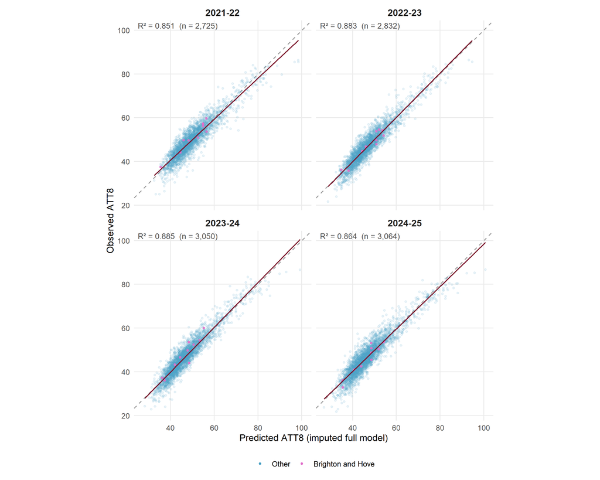

Figure 14: Observed vs predicted Attainment 8 — All Pupils (imputed full model, by year). Brighton and Hove schools in pink.

```r
HIGHLIGHT_LA <- "Brighton and Hove"

# Prepare data with highlight flag
pred_data <- panel_data %>%
  filter(!is.na(predicted_ATT8SCR_imputed), !is.na(ATT8SCR)) %>%
  mutate(
    residual = ATT8SCR - predicted_ATT8SCR_imputed,
    abs_resid = abs(residual),
    highlight = ifelse(LANAME == HIGHLIGHT_LA, HIGHLIGHT_LA, "Other"),
    highlight = factor(highlight, levels = c("Other", HIGHLIGHT_LA))
  ) %>%
  arrange(highlight)   # draw highlighted points on top

# Per-year R² labels
r2_labels <- pred_data %>%
  group_by(year_label) %>%
  summarise(
    r2 = cor(ATT8SCR, predicted_ATT8SCR_imputed, use = "complete.obs")^2,
    n  = n(),
    .groups = "drop"
  ) %>%
  mutate(label = paste0("R\u00b2 = ", round(r2, 3), "  (n = ", scales::comma(n), ")"))

ggplot(pred_data, aes(x = predicted_ATT8SCR_imputed, y = ATT8SCR)) +
  geom_abline(slope = 1, intercept = 0, colour = "grey60",
              linewidth = 0.5, linetype = "dashed") +
  geom_point(aes(colour = highlight, alpha = highlight), size = 1) +
  geom_smooth(method = "lm", se = FALSE, colour = "#7b132b", linewidth = 0.6) +
  geom_text(data = r2_labels,
            aes(x = -Inf, y = Inf, label = label),
            inherit.aes = FALSE, hjust = -0.05, vjust = 1.4,
            size = 3.3, colour = "grey30") +
  scale_colour_manual(values = c("Other" = "#49a0c4",
                                  "Brighton and Hove" = "#e16fca")) +
  scale_alpha_manual(values = c("Other" = 0.12,
                                 "Brighton and Hove" = 0.85), guide = "none") +
  facet_wrap(~ year_label, ncol = 2) +
  labs(x = "Predicted ATT8 (imputed full model)", y = "Observed ATT8",
       colour = NULL) +
  coord_equal() +
  theme_pub +
  theme(legend.position = "bottom",
        strip.text = element_text(size = 11))
```

```r
library(plotly)
library(dplyr)
library(scales)

# 1. Prepare data (same as your original logic)
pred_data <- panel_data %>%
  filter(!is.na(predicted_ATT8SCR_imputed), !is.na(ATT8SCR)) %>%
  mutate(
    residual = ATT8SCR - predicted_ATT8SCR_imputed,
    highlight = ifelse(LANAME == HIGHLIGHT_LA, HIGHLIGHT_LA, "Other"),
    highlight = factor(highlight, levels = c("Other", HIGHLIGHT_LA)),
    # Custom tooltip text
    tooltip_text = paste0(
      "LA: ", LANAME,
      "<br>Sch:", SCHNAME,
      "<br>Observed: ", round(ATT8SCR, 2),
      "<br>Predicted: ", round(predicted_ATT8SCR_imputed, 2),
      "<br>Residual: ", round(residual, 2)
    )
  ) %>%
  arrange(highlight)

# 2. Calculate R² labels
r2_labels <- pred_data %>%
  group_by(year_label) %>%
  summarise(
    r2 = cor(ATT8SCR, predicted_ATT8SCR_imputed, use = "complete.obs")^2,
    n  = n(),
    .groups = "drop"
  ) %>%
  mutate(label = paste0("R² = ", round(r2, 3), " (n = ", comma(n), ")"))

# 3. Build the ggplot object
p <- ggplot(pred_data, aes(x = predicted_ATT8SCR_imputed, y = ATT8SCR)) +
  geom_abline(slope = 1, intercept = 0, colour = "grey60",
              linewidth = 0.5, linetype = "dashed") +
  # We add 'text' aesthetic here for the Plotly tooltip
  geom_point(aes(colour = highlight, alpha = highlight, text = tooltip_text), size = 1) +
  geom_smooth(method = "lm", se = FALSE, colour = "#7b132b", linewidth = 0.6) +
  # Note: geom_text can be finicky in ggplotly; using explicit coordinates helps
  geom_text(data = r2_labels,
            aes(x = 20, y = 85, label = label),
            inherit.aes = FALSE, size = 3, colour = "grey30") +
  scale_colour_manual(values = c("Other" = "#49a0c4",
                                 "Brighton and Hove" = "#e16fca")) +
  scale_alpha_manual(values = c("Other" = 0.2,
                                "Brighton and Hove" = 0.9), guide = "none") +
  facet_wrap(~ year_label, ncol = 2) +
  labs(x = "Predicted ATT8 (imputed full model)", y = "Observed ATT8", colour = NULL) +
  theme_minimal() + # Use minimal for cleaner plotly conversion
  theme(legend.position = "bottom")

# 4. Convert to Plotly
ggplotly(p, tooltip = "text") %>%
  layout(
    legend = list(orientation = "h", x = 0.4, y = -0.1),
    margin = list(t = 50) # Space for facet titles
  )
```

[interactive chart not shown]

## 8.2 Disadvantaged Pupils

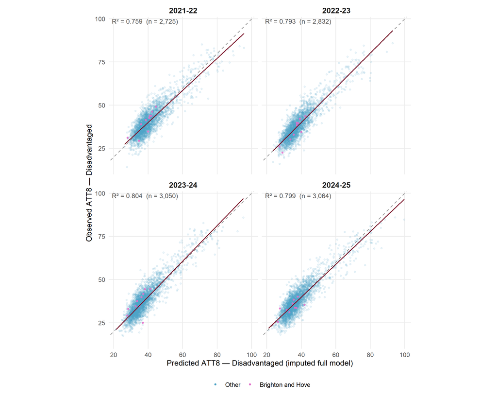

Figure 15: Observed vs predicted Attainment 8 — Disadvantaged Pupils (imputed full model, by year). Brighton and Hove schools in pink.

```r
pred_disadv <- panel_data %>%
  filter(!is.na(predicted_ATT8SCR_FSM6CLA1A_imputed), !is.na(ATT8SCR_FSM6CLA1A)) %>%
  mutate(
    highlight = ifelse(LANAME == HIGHLIGHT_LA, HIGHLIGHT_LA, "Other"),
    highlight = factor(highlight, levels = c("Other", HIGHLIGHT_LA))
  ) %>%
  arrange(highlight)

r2_disadv <- pred_disadv %>%
  group_by(year_label) %>%
  summarise(
    r2 = cor(ATT8SCR_FSM6CLA1A, predicted_ATT8SCR_FSM6CLA1A_imputed,
             use = "complete.obs")^2,
    n  = n(),
    .groups = "drop"
  ) %>%
  mutate(label = paste0("R\u00b2 = ", round(r2, 3), "  (n = ", scales::comma(n), ")"))

ggplot(pred_disadv, aes(x = predicted_ATT8SCR_FSM6CLA1A_imputed,
                         y = ATT8SCR_FSM6CLA1A)) +
  geom_abline(slope = 1, intercept = 0, colour = "grey60",
              linewidth = 0.5, linetype = "dashed") +
  geom_point(aes(colour = highlight, alpha = highlight), size = 1) +
  geom_smooth(method = "lm", se = FALSE, colour = "#7b132b", linewidth = 0.6) +
  geom_text(data = r2_disadv,
            aes(x = -Inf, y = Inf, label = label),
            inherit.aes = FALSE, hjust = -0.05, vjust = 1.4,
            size = 3.3, colour = "grey30") +
  scale_colour_manual(values = c("Other" = "#49a0c4",
                                  "Brighton and Hove" = "#e16fca")) +
  scale_alpha_manual(values = c("Other" = 0.12,
                                 "Brighton and Hove" = 0.85), guide = "none") +
  facet_wrap(~ year_label, ncol = 2) +
  labs(x = "Predicted ATT8 — Disadvantaged (imputed full model)",
       y = "Observed ATT8 — Disadvantaged",
       colour = NULL) +
  coord_equal() +
  theme_pub +
  theme(legend.position = "bottom",
        strip.text = element_text(size = 11))
```

```r
library(plotly)
library(dplyr)
library(scales)

# 1. Prepare data for Disadvantaged subset
pred_disadv <- panel_data %>%
  filter(!is.na(predicted_ATT8SCR_FSM6CLA1A_imputed), !is.na(ATT8SCR_FSM6CLA1A)) %>%
  mutate(
    residual = ATT8SCR_FSM6CLA1A - predicted_ATT8SCR_FSM6CLA1A_imputed,
    highlight = ifelse(LANAME == HIGHLIGHT_LA, HIGHLIGHT_LA, "Other"),
    highlight = factor(highlight, levels = c("Other", HIGHLIGHT_LA)),
    # Enhanced tooltip for disadvantaged context
    tooltip_text = paste0(
      "<b>", SCHNAME, "</b><br>",  # Assumes SCHNAME exists in your data
      "LA: ", LANAME,
      "<br>Sch:", SCHNAME,
      "<br>Observed (Disadv): ", round(ATT8SCR_FSM6CLA1A, 2),
      "<br>Predicted (Disadv): ", round(predicted_ATT8SCR_FSM6CLA1A_imputed, 2),
      "<br>Residual: ", round(residual, 2)
    )
  ) %>%
  arrange(highlight)

# 2. Calculate R² for the Disadvantaged model
r2_disadv_stats <- pred_disadv %>%
  group_by(year_label) %>%
  summarise(
    r2 = cor(ATT8SCR_FSM6CLA1A, predicted_ATT8SCR_FSM6CLA1A_imputed, use = "complete.obs")^2,
    n  = n(),
    .groups = "drop"
  ) %>%
  mutate(label = paste0("R² = ", round(r2, 3), " (n = ", comma(n), ")"))

# 3. Build the ggplot object
p_disadv <- ggplot(pred_disadv, aes(x = predicted_ATT8SCR_FSM6CLA1A_imputed,
                                   y = ATT8SCR_FSM6CLA1A)) +
  geom_abline(slope = 1, intercept = 0, colour = "grey60",
              linewidth = 0.5, linetype = "dashed") +
  geom_point(aes(colour = highlight, alpha = highlight, text = tooltip_text), size = 1.2) +
  geom_smooth(method = "lm", se = FALSE, colour = "#7b132b", linewidth = 0.6) +
  # Positioning labels at safe numeric coordinates (e.g., x=10, y=85)
  geom_text(data = r2_disadv_stats,
            aes(x = 10, y = 85, label = label),
            inherit.aes = FALSE, size = 3, colour = "grey30", hjust = 0) +
  scale_colour_manual(values = c("Other" = "#49a0c4",
                                 "Brighton and Hove" = "#e16fca")) +
  scale_alpha_manual(values = c("Other" = 0.15,
                                "Brighton and Hove" = 0.9), guide = "none") +
  facet_wrap(~ year_label, ncol = 2) +
  labs(x = "Predicted ATT8 — Disadvantaged",
       y = "Observed ATT8 — Disadvantaged",
       colour = NULL) +
  theme_minimal() +
  theme(legend.position = "bottom",
        strip.text = element_text(face = "bold"))

# 4. Final Plotly conversion
ggplotly(p_disadv, tooltip = "text") %>%
  layout(
    legend = list(orientation = "h", x = 0.3, y = -0.15),
    margin = list(t = 60)
  )
```

[interactive chart not shown]

## 8.3 Non-Disadvantaged Pupils

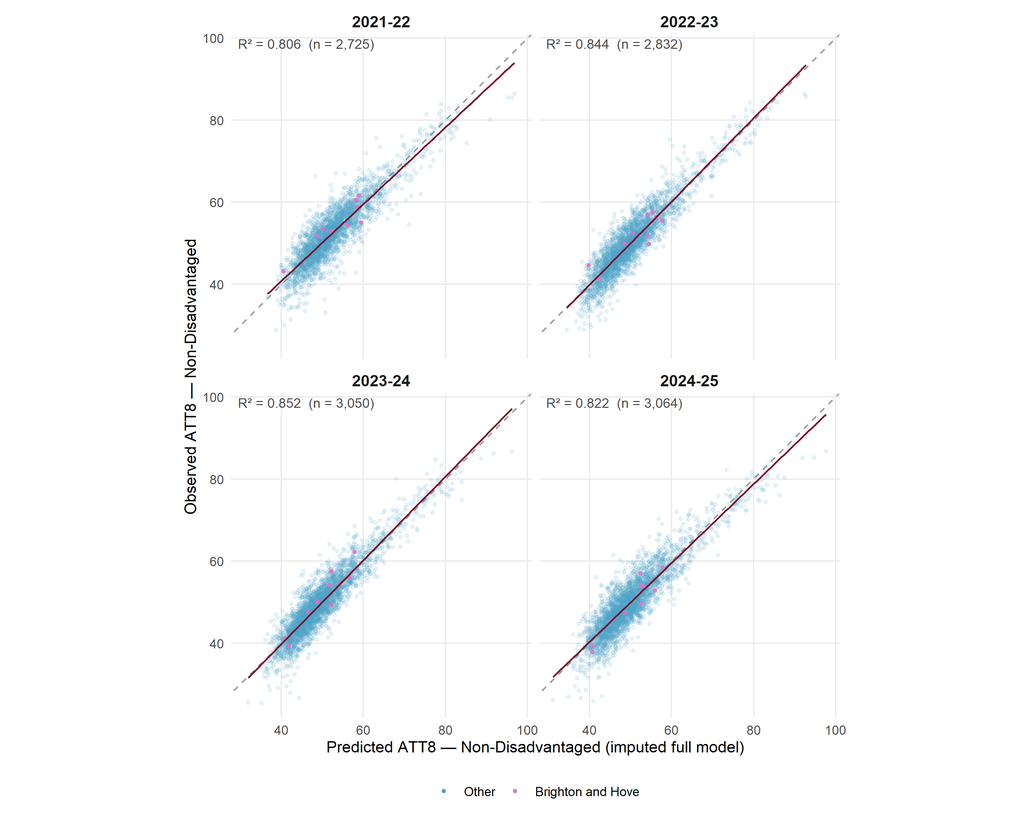

Figure 16: Observed vs predicted Attainment 8 — Non-Disadvantaged Pupils (imputed full model, by year). Brighton and Hove schools in pink.

```r
pred_nondisadv <- panel_data %>%
  filter(!is.na(predicted_ATT8SCR_NFSM6CLA1A_imputed), !is.na(ATT8SCR_NFSM6CLA1A)) %>%
  mutate(
    highlight = ifelse(LANAME == HIGHLIGHT_LA, HIGHLIGHT_LA, "Other"),
    highlight = factor(highlight, levels = c("Other", HIGHLIGHT_LA))
  ) %>%
  arrange(highlight)

r2_nondisadv <- pred_nondisadv %>%
  group_by(year_label) %>%
  summarise(
    r2 = cor(ATT8SCR_NFSM6CLA1A, predicted_ATT8SCR_NFSM6CLA1A_imputed,
             use = "complete.obs")^2,
    n  = n(),
    .groups = "drop"
  ) %>%
  mutate(label = paste0("R\u00b2 = ", round(r2, 3), "  (n = ", scales::comma(n), ")"))

ggplot(pred_nondisadv, aes(x = predicted_ATT8SCR_NFSM6CLA1A_imputed,
                            y = ATT8SCR_NFSM6CLA1A)) +
  geom_abline(slope = 1, intercept = 0, colour = "grey60",
              linewidth = 0.5, linetype = "dashed") +
  geom_point(aes(colour = highlight, alpha = highlight), size = 1) +
  geom_smooth(method = "lm", se = FALSE, colour = "#7b132b", linewidth = 0.6) +
  geom_text(data = r2_nondisadv,
            aes(x = -Inf, y = Inf, label = label),
            inherit.aes = FALSE, hjust = -0.05, vjust = 1.4,
            size = 3.3, colour = "grey30") +
  scale_colour_manual(values = c("Other" = "#49a0c4",
                                  "Brighton and Hove" = "#e16fca")) +
  scale_alpha_manual(values = c("Other" = 0.12,
                                 "Brighton and Hove" = 0.85), guide = "none") +
  facet_wrap(~ year_label, ncol = 2) +
  labs(x = "Predicted ATT8 — Non-Disadvantaged (imputed full model)",
       y = "Observed ATT8 — Non-Disadvantaged",
       colour = NULL) +
  coord_equal() +
  theme_pub +
  theme(legend.position = "bottom",
        strip.text = element_text(size = 11))
```

```r
library(plotly)
library(dplyr)
library(scales)

# 1. Prepare data for Non-Disadvantaged subset
pred_nondisadv <- panel_data %>%
  filter(!is.na(predicted_ATT8SCR_NFSM6CLA1A_imputed), !is.na(ATT8SCR_NFSM6CLA1A)) %>%
  mutate(
    residual = ATT8SCR_NFSM6CLA1A - predicted_ATT8SCR_NFSM6CLA1A_imputed,
    highlight = ifelse(LANAME == HIGHLIGHT_LA, HIGHLIGHT_LA, "Other"),
    highlight = factor(highlight, levels = c("Other", HIGHLIGHT_LA)),
    # Custom tooltip
    tooltip_text = paste0(
      "<b>", SCHNAME, "</b><br>",
      "LA: ", LANAME,
      "<br>Sch:", SCHNAME,
      "<br>Observed (Non-Disadv): ", round(ATT8SCR_NFSM6CLA1A, 2),
      "<br>Predicted (Non-Disadv): ", round(predicted_ATT8SCR_NFSM6CLA1A_imputed, 2),
      "<br>Residual: ", round(residual, 2)
    )
  ) %>%
  arrange(highlight)

# 2. Calculate R² for the Non-Disadvantaged model
r2_nondisadv_stats <- pred_nondisadv %>%
  group_by(year_label) %>%
  summarise(
    r2 = cor(ATT8SCR_NFSM6CLA1A, predicted_ATT8SCR_NFSM6CLA1A_imputed, use = "complete.obs")^2,
    n  = n(),
    .groups = "drop"
  ) %>%
  mutate(label = paste0("R² = ", round(r2, 3), " (n = ", comma(n), ")"))

# 3. Build the ggplot object
p_nondisadv <- ggplot(pred_nondisadv, aes(x = predicted_ATT8SCR_NFSM6CLA1A_imputed,
                                         y = ATT8SCR_NFSM6CLA1A)) +
  geom_abline(slope = 1, intercept = 0, colour = "grey60",
              linewidth = 0.5, linetype = "dashed") +
  geom_point(aes(colour = highlight, alpha = highlight, text = tooltip_text), size = 1.2) +
  geom_smooth(method = "lm", se = FALSE, colour = "#7b132b", linewidth = 0.6) +
  # Placed at higher coordinates as Non-Disadv scores are typically higher
  geom_text(data = r2_nondisadv_stats,
            aes(x = 20, y = 88, label = label),
            inherit.aes = FALSE, size = 3, colour = "grey30", hjust = 0) +
  scale_colour_manual(values = c("Other" = "#49a0c4",
                                 "Brighton and Hove" = "#e16fca")) +
  scale_alpha_manual(values = c("Other" = 0.15,
                                "Brighton and Hove" = 0.9), guide = "none") +
  facet_wrap(~ year_label, ncol = 2) +
  labs(x = "Predicted ATT8 — Non-Disadvantaged",
       y = "Observed ATT8 — Non-Disadvantaged",
       colour = NULL) +
  theme_minimal() +
  theme(legend.position = "bottom",
        strip.text = element_text(face = "bold"))

# 4. Final Plotly conversion
ggplotly(p_nondisadv, tooltip = "text") %>%
  layout(
    legend = list(orientation = "h", x = 0.3, y = -0.15),
    margin = list(t = 60)
  )
```

[interactive chart not shown]

# 9 Residual Geography

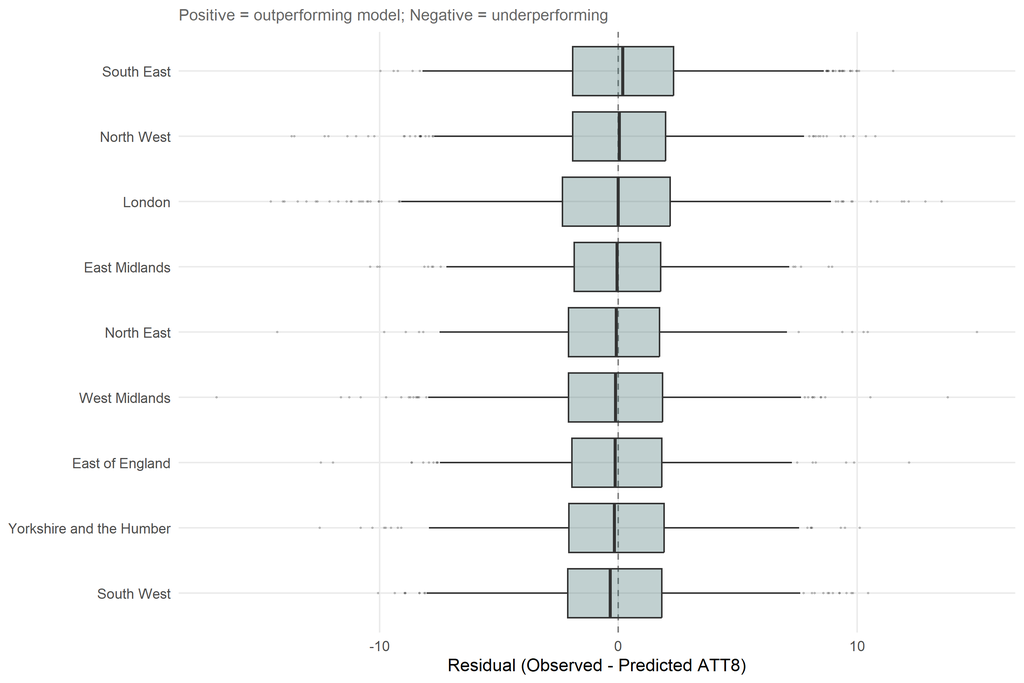

Figure 17: Distribution of model residuals by Government Office Region

```r
if ("gor_name" %in% names(pred_data) && sum(!is.na(pred_data$gor_name)) > 0) {

  region_resid <- pred_data %>%
    filter(!is.na(gor_name)) %>%
    group_by(gor_name) %>%
    summarise(
      mean_resid = mean(residual, na.rm = TRUE),
      median_resid = median(residual, na.rm = TRUE),
      n = n(),
      .groups = "drop"
    ) %>%
    arrange(mean_resid)

  ggplot(pred_data %>% filter(!is.na(gor_name)),
         aes(x = reorder(gor_name, residual, FUN = median), y = residual)) +
    geom_hline(yintercept = 0, linetype = "dashed", colour = "grey50") +
    geom_boxplot(fill = "#2e6260", alpha = 0.3, outlier.size = 0.3, outlier.alpha = 0.2) +
    coord_flip() +
    labs(x = NULL, y = "Residual (Observed - Predicted ATT8)",
         subtitle = "Positive = outperforming model; Negative = underperforming") +
    theme_pub
}
```

# 10 Disadvantage Gap

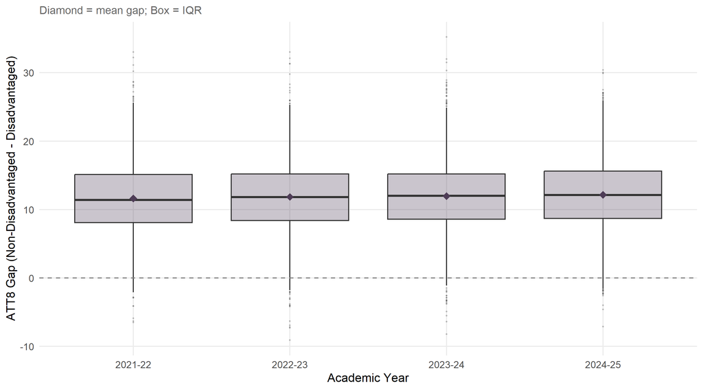

Figure 18: Disadvantage attainment gap by academic year

```r
if (all(c("ATT8SCR_FSM6CLA1A", "ATT8SCR_NFSM6CLA1A") %in% names(model_data))) {
  gap_data <- model_data %>%
    filter(!is.na(ATT8SCR_FSM6CLA1A), !is.na(ATT8SCR_NFSM6CLA1A)) %>%
    mutate(gap = ATT8SCR_NFSM6CLA1A - ATT8SCR_FSM6CLA1A)

  gap_summary <- gap_data %>%
    group_by(year_label) %>%
    summarise(
      mean_gap = mean(gap, na.rm = TRUE),
      median_gap = median(gap, na.rm = TRUE),
      q25 = quantile(gap, 0.25, na.rm = TRUE),
      q75 = quantile(gap, 0.75, na.rm = TRUE),
      .groups = "drop"
    )

  ggplot(gap_data, aes(x = year_label, y = gap)) +
    geom_boxplot(fill = "#4e3c56", alpha = 0.3, outlier.size = 0.3, outlier.alpha = 0.2) +
    geom_point(data = gap_summary, aes(y = mean_gap),
               colour = "#4e3c56", size = 3, shape = 18) +
    geom_hline(yintercept = 0, linetype = "dashed", colour = "grey50") +
    labs(x = "Academic Year",
         y = "ATT8 Gap (Non-Disadvantaged - Disadvantaged)",
         subtitle = "Diamond = mean gap; Box = IQR") +
    theme_pub
}
```

## 11 Appendix: Model Formulae

## 11.1 Panel Model (Analysis A)

```
log(ATT8SCR) ~ log(PTFSM6CLA1A) + log(PERCTOT) + log(PNUMEAL) +
  ks2_c + ADMPOL_PT + gorard_segregation +
  remained_in_the_same_school +
  teachers_on_leadership_pay_range_percent +
  log(average_number_of_days_taken) +
  (1 | year_label) + (1 | OFSTEDRATING_1) + (1 | gor_name/LANAME)
```

## 11.2 Per-Year Model (Analysis B)

Separate model for each academic year (no year term):

```
log(ATT8SCR) ~ log(PTFSM6CLA1A) + log(PERCTOT) + log(PNUMEAL) +
  ks2_c + ADMPOL_PT + gorard_segregation +
  remained_in_the_same_school +
  teachers_on_leadership_pay_range_percent +
  log(average_number_of_days_taken) +
  (1 | OFSTEDRATING_1) + (1 | gor_name/LANAME)
```

## 11.3 Core Panel Model (Analysis C)

Reduced specification using only the 5 predictors available for all 4 years (including 2024-25). Drops workforce and prior-attainment variables:

```
log(ATT8SCR) ~ log(PTFSM6CLA1A) + log(PERCTOT) + log(PNUMEAL) +
  ADMPOL_PT + gorard_segregation +
  (1 | year_label) + (1 | OFSTEDRATING_1) + (1 | gor_name/LANAME)
```

## 11.4 Core Per-Year Model (Analysis D)

Same 5 core fixed effects, separate model per year (no year term):

```
log(ATT8SCR) ~ log(PTFSM6CLA1A) + log(PERCTOT) + log(PNUMEAL) +
  ADMPOL_PT + gorard_segregation +
  (1 | OFSTEDRATING_1) + (1 | gor_name/LANAME)
```

## 11.5 Imputed Full Panel Model (Analysis E)

Same 9-predictor specification as Analysis A, but covering all 4 years (2024-25 uses carry-forward imputed workforce and prior-attainment values). This is the model used in the Shiny app and for Observed vs Predicted plots.

```
log(ATT8SCR) ~ log(PTFSM6CLA1A) + log(PERCTOT) + log(PNUMEAL) +
  ks2_c + ADMPOL_PT + gorard_segregation +
  remained_in_the_same_school +
  teachers_on_leadership_pay_range_percent +
  log(average_number_of_days_taken) +
  (1 | year_label) + (1 | OFSTEDRATING_1) + (1 | gor_name/LANAME)
```

## 11.6 Variable Definitions

```r
model_vars <- c(
  "ATT8SCR", "ATT8SCR_FSM6CLA1A", "ATT8SCR_NFSM6CLA1A",
  "PTFSM6CLA1A", "PERCTOT", "PNUMEAL", "KS2ASS",
  "ADMPOL_PT", "gorard_segregation",
  "remained_in_the_same_school",
  "teachers_on_leadership_pay_range_percent",
  "average_number_of_days_taken",
  "OFSTEDRATING_1", "gor_name", "LANAME", "year_label"
)

tibble(
  `Variable Code` = model_vars,
  Description = var_labels(model_vars),
  `In Formula As` = case_when(
    model_vars %in% c("PTFSM6CLA1A", "PERCTOT", "PNUMEAL",
                       "remained_in_the_same_school",
                       "average_number_of_days_taken",
                       "ATT8SCR", "ATT8SCR_FSM6CLA1A", "ATT8SCR_NFSM6CLA1A") ~
      paste0("log(", model_vars, ")"),
    model_vars %in% c("OFSTEDRATING_1", "gor_name", "LANAME", "year_label") ~
      paste0("(1 | ", model_vars, ")"),
    model_vars == "ADMPOL_PT" ~
      "Two dummy variables (treatment-coded): ADMPOL_PTOTHER NON SEL, ADMPOL_PTSEL (ref: non-sel. in highly sel. area)",
    TRUE ~ model_vars
  ),
  Source = case_when(
    model_vars %in% c("ATT8SCR", "ATT8SCR_FSM6CLA1A", "ATT8SCR_NFSM6CLA1A",
                       "PTFSM6CLA1A", "KS2ASS", "ADMPOL_PT") ~ "KS4 Performance Tables",
    model_vars %in% c("PERCTOT") ~ "Absence Statistics",
    model_vars %in% c("PNUMEAL") ~ "School Census",
    model_vars %in% c("OFSTEDRATING_1") ~ "Ofsted Inspections (harmonised)",
    model_vars %in% c("gorard_segregation") ~ "Derived (Gorard index)",
    model_vars %in% c("remained_in_the_same_school",
                       "teachers_on_leadership_pay_range_percent",
                       "average_number_of_days_taken") ~ "School Workforce Census",
    model_vars %in% c("gor_name", "LANAME") ~ "Edubase",
    model_vars == "year_label" ~ "Constructed",
    TRUE ~ ""
  )
) %>%
  kable(align = "llll") %>%
  kable_styling(bootstrap_options = c("striped", "hover", "condensed"),
                full_width = FALSE, font_size = 10)
```

Table 15: Variable definitions from DfE metadata

| Variable Code | Description | In Formula As | Source |
| --- | --- | --- | --- |
| ATT8SCR | Avg. Attainment 8 score per pupil | log(ATT8SCR) | KS4 Performance Tables |
| ATT8SCR_FSM6CLA1A | Avg. Attainment 8 score (disadvantaged) | log(ATT8SCR_FSM6CLA1A) | KS4 Performance Tables |
| ATT8SCR_NFSM6CLA1A | Avg. Attainment 8 score (non-disadvantaged) | log(ATT8SCR_NFSM6CLA1A) | KS4 Performance Tables |
| PTFSM6CLA1A | % KS4 pupils who are disadvantaged | log(PTFSM6CLA1A) | KS4 Performance Tables |
| PERCTOT | % overall absence | log(PERCTOT) | Absence Statistics |
| PNUMEAL | % pupils with English not first language | log(PNUMEAL) | School Census |
| KS2ASS | KS2ASS | KS2ASS | KS4 Performance Tables |
| ADMPOL_PT | Admissions policy (new definition from 2019) | Two dummy variables (treatment-coded): ADMPOL_PTOTHER NON SEL, ADMPOL_PTSEL (ref: non-sel. in highly sel. area) | KS4 Performance Tables |
| gorard_segregation | Gorard segregation index | gorard_segregation | Derived (Gorard index) |
| remained_in_the_same_school | Teachers remaining in same school (FTE) | log(remained_in_the_same_school) | School Workforce Census |
| teachers_on_leadership_pay_range_percent | % teachers on leadership pay range | teachers_on_leadership_pay_range_percent | School Workforce Census |
| average_number_of_days_taken | Avg. teacher sickness days | log(average_number_of_days_taken) | School Workforce Census |
| OFSTEDRATING_1 | Ofsted rating (harmonised) | (1 &#124; OFSTEDRATING_1) | Ofsted Inspections (harmonised) |
| gor_name | Government Office Region | (1 &#124; gor_name) | Edubase |
| LANAME | Local authority name | (1 &#124; LANAME) | Edubase |
| year_label | Academic year (short) | (1 &#124; year_label) | Constructed |

[UCL Centre for Advanced Spatial Analysis](https://www.ucl.ac.uk/bartlett/casa) · School Attainment Tool